# COVID-19 Pandemic, Disability, and Financial Well-Being

Data Analysis Notes

Vivekananda Das

20 September, 2022

## Data Analysis Plan

**Background** Conventional Knowledge: the disabled face more financial hardship compared to the non-disabled.

**Ideal Question** Did the pandemic make things worse for the disabled?

**Data** Household Pulse Survey. Begins in April 2020. No Pulse data in the pre-pandemic world. No truly pre period.

**Refined Question** Compared to the first three months in the pandemic, did the difference in financial hardship between the disabled and the non-disabled change over time?

**Identifying the disabled** - Aged 18-64 - Enrolled in Medicare

**Characteristics of the disabled** - More likely to be lower-income - More likely to have lower educational attainment - More likely to be non-white

**Time Periods**

| Quarterly Periods | Pulse Weeks | Captured Months, Year |
| --- | --- | --- |
| 1 | 1-9 | April-June, 2020 |
| 2 | 10-15 | July-September, 2020 |
| 3 | 16-21 | October-December, 2020 |
| 4 | 22-27 | January-March, 2021 |
| 5 | 28-33 | April-June, 2021 |
| 6 | 34-38 | July-September, 2021 |
| 7 | 39-40 | October-December, 2021 |

**Outcome Variables** 1= facing hardship, 0 = not facing hardship

**1) Food Insufficiency**

*Getting enough food can also be a problem for some people. In the last 7 days, which of these statements best describes the food eaten in your household? Select only one answer.*

1. Enough of the kinds of food (I/we) wanted to eat (0)
2. Enough, but not always the kinds of food (I/we) wanted to eat (0)
3. Sometimes not enough to eat (1)
4. Often not enough to eat (1)

**2) Difficulty with Expenses**

*In the last 7 days, how difficult has it been for your household to pay for usual household expenses, including but not limited to food, rent or mortgage, car payments, medical expenses, student loans, and so on? Select only one answer.*

1. Not at all difficult (0)
2. A little difficult (0)
3. Somewhat difficult (1)
4. Very difficult (1)

**3) Confidence in Paying Rent/Mortgage**

*How confident are you that your household will be able to pay your next rent or mortgage payment on time? Select only one answer.*

1. Not at all confident (1)
2. Slightly confident (1)
3. Moderately confident (0)
4. Highly confident (0)
5. Payment is/will be deferred (0)

**All the outcome measures are binary. A score of 1 indicates financial hardship, a score of 0 indicates otherwise**

**Target Estimand**

For each period n (where, n = [1,6]),

(Average outcome for the disabled in period 1+n - Average outcome for the disabled in period 1) - (Average outcome for the non-disabled in period 1+n - Average outcome for the non-disabled in period 1)

*If the above quantity is +*  
⇒ Greater increase in hardship for the disabled compared to the non-disabled over time ⇒ The disabled were more likely to be in hardship

*If the above quantity is -*  
⇒ Lower increase in hardship for the disabled compared to the non-disabled over time ⇒ The disabled were less likely to be in hardship

**Empirical Model** Outcome = b0 + b1xMedicare + b2xPeriod2 + b3xPeriod3 + b4xPeriod4 + b5xPeriod5 + b6xPeriod6 + b7xPeriod7 + b8xMedicarexPeriod2 + b9xMedicarexPeriod3 + b10xMedicarexPeriod4 + b11xMedicarexPeriod5 + b12xMedicarexPeriod6 + b13xMedicarexPeriod7+ u

where, Medicare is a dummy which takes a value of 1 if a respondent is enrolled in Medicare and a 0 otherwise.

## Food Insufficiency

### Preparing the analytical sample

```r
###Load Data
load("hps_data_foodinsuf.RData")

###Age variable
data$AGE<-2022-data$TBIRTH_YEAR

###Create Period
data<- data %>% filter(WEEK<=40,)

data$Period <- as.factor(ifelse(data$WEEK >=1 & data$WEEK <=9, '1.April-June,2020',
                                ifelse(data$WEEK >=10 & data$WEEK <=15, '2.July-September,2020',
                                       ifelse(data$WEEK >=16 & data$WEEK <=21, '3.October-December,2020',
                                              ifelse(data$WEEK >=22 & data$WEEK <=27, '4.January-March,2021',
                                                     ifelse(data$WEEK >=28 & data$WEEK <=33, '5.April-June,2021',
                                                            ifelse(data$WEEK >=34 & data$WEEK <=38, '6.July-September,2021','7.October-December,2021')))))))


##Disabled Identification

#Selecting people aged 18-64 and those who responded to the Medicare question
data.18.65<-data %>% filter (AGE>=18 & AGE <=64 & HLTHINS3>=0)


##Creating a disability dummy
data.18.65$MDCR.DIS<-ifelse(data.18.65$HLTHINS3==1,"Disabled","Not-disabled")
table(data.18.65$MDCR.DIS,exclude=NULL)
```

```
##
##     Disabled Not-disabled
##        94441      1637596
```

```r
##Releveling to make the non-disabled the reference category
data.18.65$MDCR.DIS<-relevel(factor(data.18.65$MDCR.DIS),ref="Not-disabled")


##Creating food insufficiency dummy
table(data.18.65$CURFOODSUF,exclude = NULL)
```

```
##
##     -99       1       2       3       4
##    2929 1164868  427697  107912   28631
```

```r
data.18.65<-data.18.65 %>% filter(CURFOODSUF>=0,)
data.18.65$food_insuf<-ifelse(data.18.65$CURFOODSUF==3|data.18.65$CURFOODSUF==4,1,0)
table(data.18.65$food_insuf,exclude = NULL)
```

```
##
##       0       1
## 1592565  136543
```

```r
##Multiplying food insufficiency by 100 to create percentages
data.18.65$food_insuf<-(data.18.65$food_insuf)*100
table(data.18.65$food_insuf)
```

```
##
##       0     100
## 1592565  136543
```

### Descriptive Findings

```r
##Overall Sample
table1(~ food_insuf+factor(EGENDER)+factor(RRACE)+factor(INCOME)+factor(RHISPANIC)+AGE+factor(TENURE)+factor(MS)+factor(EEDUC)+THHLD_NUMKID+THHLD_NUMPER| MDCR.DIS, data.18.65,overall = FALSE)
```

|  | Not-disabled (N=1635029) | Disabled (N=94079) |
| --- | --- | --- |
| food_insuf |  |  |
| Mean (SD) | 7.35 (26.1) | 17.4 (37.9) |
| Median [Min, Max] | 0 [0, 100] | 0 [0, 100] |
| factor(EGENDER) |  |  |
| 1 | 629776 (38.5%) | 30600 (32.5%) |
| 2 | 1005253 (61.5%) | 63479 (67.5%) |
| factor(RRACE) |  |  |
| 1 | 1320824 (80.8%) | 71009 (75.5%) |
| 2 | 134167 (8.2%) | 11608 (12.3%) |
| 3 | 90901 (5.6%) | 4519 (4.8%) |
| 4 | 89137 (5.5%) | 6943 (7.4%) |
| factor(INCOME) |  |  |
| -99 | 25373 (1.6%) | 1920 (2.0%) |
| -88 | 78520 (4.8%) | 4990 (5.3%) |
| 1 | 145658 (8.9%) | 29689 (31.6%) |
| 2 | 118622 (7.3%) | 11920 (12.7%) |
| 3 | 152567 (9.3%) | 10504 (11.2%) |
| 4 | 255135 (15.6%) | 13431 (14.3%) |
| 5 | 223248 (13.7%) | 8138 (8.7%) |
| 6 | 302052 (18.5%) | 7725 (8.2%) |
| 7 | 151974 (9.3%) | 3046 (3.2%) |
| 8 | 181880 (11.1%) | 2716 (2.9%) |
| factor(RHISPANIC) |  |  |
| 1 | 1466373 (89.7%) | 83878 (89.2%) |
| 2 | 168656 (10.3%) | 10201 (10.8%) |
| AGE |  |  |
| Mean (SD) | 45.5 (11.1) | 52.9 (9.94) |
| Median [Min, Max] | 45.0 [19.0, 64.0] | 56.0 [19.0, 64.0] |
| factor(TENURE) |  |  |
| -99 | 4677 (0.3%) | 586 (0.6%) |
| -88 | 30941 (1.9%) | 2255 (2.4%) |
| 1 | 247034 (15.1%) | 22260 (23.7%) |
| 2 | 871993 (53.3%) | 36325 (38.6%) |
| 3 | 459519 (28.1%) | 30847 (32.8%) |
| 4 | 20865 (1.3%) | 1806 (1.9%) |
| factor(MS) |  |  |
| -99 | 5376 (0.3%) | 706 (0.8%) |
| 1 | 949974 (58.1%) | 43037 (45.7%) |
| 2 | 24651 (1.5%) | 4563 (4.9%) |
| 3 | 217631 (13.3%) | 21405 (22.8%) |
| 4 | 33254 (2.0%) | 3269 (3.5%) |
| 5 | 404143 (24.7%) | 21099 (22.4%) |
| factor(EEDUC) |  |  |
| 1 | 8925 (0.5%) | 1343 (1.4%) |
| 2 | 22076 (1.4%) | 2993 (3.2%) |
| 3 | 171146 (10.5%) | 18217 (19.4%) |
| 4 | 336520 (20.6%) | 27991 (29.8%) |
| 5 | 172658 (10.6%) | 13454 (14.3%) |
| 6 | 513304 (31.4%) | 18275 (19.4%) |
| 7 | 410400 (25.1%) | 11806 (12.5%) |
| THHLD_NUMKID |  |  |
| Mean (SD) | 0.873 (1.15) | 0.542 (0.989) |
| Median [Min, Max] | 0 [0, 5.00] | 0 [0, 5.00] |
| THHLD_NUMPER |  |  |
| Mean (SD) | 3.06 (1.53) | 2.88 (1.69) |
| Median [Min, Max] | 3.00 [1.00, 10.0] | 2.00 [1.00, 10.0] |

```r
##Every Period
table1(~ food_insuf+factor(EGENDER)+factor(RRACE)+factor(INCOME)+factor(RHISPANIC)+AGE+factor(TENURE)+factor(MS)+factor(EEDUC)+THHLD_NUMKID+THHLD_NUMPER| Period*MDCR.DIS, data.18.65,overall = FALSE)
```

|  | 1.April-June,2020 Not-disabled (N=441917) | 1.April-June,2020 Disabled (N=25921) | 2.July-September,2020 Not-disabled (N=312475) | 2.July-September,2020 Disabled (N=17434) | 3.October-December,2020 Not-disabled (N=230805) | 3.October-December,2020 Disabled (N=12626) | 4.January-March,2021 Not-disabled (N=211911) | 4.January-March,2021 Disabled (N=12084) | 5.April-June,2021 Not-disabled (N=205404) | 5.April-June,2021 Disabled (N=11919) | 6.July-September,2021 Not-disabled (N=170230) | 6.July-September,2021 Disabled (N=10363) | 7.October-December,2021 Not-disabled (N=62287) | 7.October-December,2021 Disabled (N=3732) |
| --- | --- | --- | --- | --- | --- | --- | --- | --- | --- | --- | --- | --- | --- | --- |
| food_insuf |  |  |  |  |  |  |  |  |  |  |  |  |  |  |
| Mean (SD) | 7.27 (26.0) | 16.5 (37.2) | 7.95 (27.1) | 17.6 (38.1) | 8.76 (28.3) | 20.7 (40.5) | 7.48 (26.3) | 17.8 (38.2) | 6.43 (24.5) | 16.4 (37.0) | 5.77 (23.3) | 16.0 (36.7) | 6.51 (24.7) | 18.0 (38.5) |
| Median [Min, Max] | 0 [0, 100] | 0 [0, 100] | 0 [0, 100] | 0 [0, 100] | 0 [0, 100] | 0 [0, 100] | 0 [0, 100] | 0 [0, 100] | 0 [0, 100] | 0 [0, 100] | 0 [0, 100] | 0 [0, 100] | 0 [0, 100] | 0 [0, 100] |
| factor(EGENDER) |  |  |  |  |  |  |  |  |  |  |  |  |  |  |
| 1 | 169323 (38.3%) | 8417 (32.5%) | 122057 (39.1%) | 5712 (32.8%) | 88731 (38.4%) | 4116 (32.6%) | 79946 (37.7%) | 3968 (32.8%) | 79478 (38.7%) | 3889 (32.6%) | 65117 (38.3%) | 3274 (31.6%) | 25124 (40.3%) | 1224 (32.8%) |
| 2 | 272594 (61.7%) | 17504 (67.5%) | 190418 (60.9%) | 11722 (67.2%) | 142074 (61.6%) | 8510 (67.4%) | 131965 (62.3%) | 8116 (67.2%) | 125926 (61.3%) | 8030 (67.4%) | 105113 (61.7%) | 7089 (68.4%) | 37163 (59.7%) | 2508 (67.2%) |
| factor(RRACE) |  |  |  |  |  |  |  |  |  |  |  |  |  |  |
| 1 | 355951 (80.5%) | 19390 (74.8%) | 251356 (80.4%) | 12991 (74.5%) | 188652 (81.7%) | 9640 (76.4%) | 171787 (81.1%) | 9156 (75.8%) | 165257 (80.5%) | 9019 (75.7%) | 137398 (80.7%) | 7912 (76.3%) | 50423 (81.0%) | 2901 (77.7%) |
| 2 | 38771 (8.8%) | 3355 (12.9%) | 26501 (8.5%) | 2215 (12.7%) | 17246 (7.5%) | 1452 (11.5%) | 16537 (7.8%) | 1421 (11.8%) | 16372 (8.0%) | 1467 (12.3%) | 13922 (8.2%) | 1288 (12.4%) | 4818 (7.7%) | 410 (11.0%) |
| 3 | 23320 (5.3%) | 1307 (5.0%) | 16874 (5.4%) | 865 (5.0%) | 12148 (5.3%) | 558 (4.4%) | 11957 (5.6%) | 607 (5.0%) | 12790 (6.2%) | 583 (4.9%) | 10041 (5.9%) | 452 (4.4%) | 3771 (6.1%) | 147 (3.9%) |
| 4 | 23875 (5.4%) | 1869 (7.2%) | 17744 (5.7%) | 1363 (7.8%) | 12759 (5.5%) | 976 (7.7%) | 11630 (5.5%) | 900 (7.4%) | 10985 (5.3%) | 850 (7.1%) | 8869 (5.2%) | 711 (6.9%) | 3275 (5.3%) | 274 (7.3%) |
| factor(INCOME) |  |  |  |  |  |  |  |  |  |  |  |  |  |  |
| -99 | 4969 (1.1%) | 412 (1.6%) | 4749 (1.5%) | 370 (2.1%) | 3949 (1.7%) | 276 (2.2%) | 3873 (1.8%) | 251 (2.1%) | 3977 (1.9%) | 274 (2.3%) | 2904 (1.7%) | 266 (2.6%) | 952 (1.5%) | 71 (1.9%) |
| -88 | 10598 (2.4%) | 693 (2.7%) | 12814 (4.1%) | 810 (4.6%) | 12435 (5.4%) | 744 (5.9%) | 11335 (5.3%) | 686 (5.7%) | 15328 (7.5%) | 971 (8.1%) | 11998 (7.0%) | 834 (8.0%) | 4012 (6.4%) | 252 (6.8%) |
| 1 | 43447 (9.8%) | 8375 (32.3%) | 28633 (9.2%) | 5427 (31.1%) | 18937 (8.2%) | 3838 (30.4%) | 17601 (8.3%) | 3719 (30.8%) | 16545 (8.1%) | 3824 (32.1%) | 14613 (8.6%) | 3208 (31.0%) | 5882 (9.4%) | 1298 (34.8%) |
| 2 | 34463 (7.8%) | 3359 (13.0%) | 23512 (7.5%) | 2248 (12.9%) | 16078 (7.0%) | 1617 (12.8%) | 14777 (7.0%) | 1527 (12.6%) | 13730 (6.7%) | 1472 (12.4%) | 11503 (6.8%) | 1229 (11.9%) | 4559 (7.3%) | 468 (12.5%) |
| 3 | 43794 (9.9%) | 3029 (11.7%) | 30265 (9.7%) | 2006 (11.5%) | 21168 (9.2%) | 1321 (10.5%) | 19634 (9.3%) | 1389 (11.5%) | 17415 (8.5%) | 1243 (10.4%) | 14654 (8.6%) | 1157 (11.2%) | 5637 (9.1%) | 359 (9.6%) |
| 4 | 72795 (16.5%) | 3887 (15.0%) | 49893 (16.0%) | 2514 (14.4%) | 35402 (15.3%) | 1830 (14.5%) | 33088 (15.6%) | 1747 (14.5%) | 29972 (14.6%) | 1609 (13.5%) | 24686 (14.5%) | 1368 (13.2%) | 9299 (14.9%) | 476 (12.8%) |
| 5 | 62194 (14.1%) | 2354 (9.1%) | 43621 (14.0%) | 1496 (8.6%) | 31725 (13.7%) | 1115 (8.8%) | 28711 (13.5%) | 1024 (8.5%) | 26811 (13.1%) | 940 (7.9%) | 22065 (13.0%) | 882 (8.5%) | 8121 (13.0%) | 327 (8.8%) |
| 6 | 82310 (18.6%) | 2219 (8.6%) | 57343 (18.4%) | 1446 (8.3%) | 43246 (18.7%) | 1077 (8.5%) | 39156 (18.5%) | 1006 (8.3%) | 37622 (18.3%) | 890 (7.5%) | 31352 (18.4%) | 808 (7.8%) | 11023 (17.7%) | 279 (7.5%) |
| 7 | 40540 (9.2%) | 845 (3.3%) | 28167 (9.0%) | 612 (3.5%) | 21847 (9.5%) | 425 (3.4%) | 19837 (9.4%) | 396 (3.3%) | 19600 (9.5%) | 362 (3.0%) | 16256 (9.5%) | 317 (3.1%) | 5727 (9.2%) | 89 (2.4%) |
| 8 | 46807 (10.6%) | 748 (2.9%) | 33478 (10.7%) | 505 (2.9%) | 26018 (11.3%) | 383 (3.0%) | 23899 (11.3%) | 339 (2.8%) | 24404 (11.9%) | 334 (2.8%) | 20199 (11.9%) | 294 (2.8%) | 7075 (11.4%) | 113 (3.0%) |
| factor(RHISPANIC) |  |  |  |  |  |  |  |  |  |  |  |  |  |  |
| 1 | 397911 (90.0%) | 23280 (89.8%) | 280038 (89.6%) | 15371 (88.2%) | 208125 (90.2%) | 11333 (89.8%) | 188327 (88.9%) | 10684 (88.4%) | 183851 (89.5%) | 10567 (88.7%) | 152311 (89.5%) | 9299 (89.7%) | 55810 (89.6%) | 3344 (89.6%) |
| 2 | 44006 (10.0%) | 2641 (10.2%) | 32437 (10.4%) | 2063 (11.8%) | 22680 (9.8%) | 1293 (10.2%) | 23584 (11.1%) | 1400 (11.6%) | 21553 (10.5%) | 1352 (11.3%) | 17919 (10.5%) | 1064 (10.3%) | 6477 (10.4%) | 388 (10.4%) |
| AGE |  |  |  |  |  |  |  |  |  |  |  |  |  |  |
| Mean (SD) | 45.2 (10.9) | 52.4 (9.99) | 45.1 (11.1) | 52.5 (10.2) | 45.3 (11.0) | 52.7 (10.0) | 45.9 (11.2) | 53.2 (9.85) | 46.3 (11.0) | 53.4 (9.66) | 45.7 (11.3) | 53.5 (9.76) | 45.2 (11.6) | 53.7 (9.73) |
| Median [Min, Max] | 45.0 [20.0, 64.0] | 55.0 [20.0, 64.0] | 45.0 [20.0, 64.0] | 55.0 [20.0, 64.0] | 45.0 [20.0, 64.0] | 56.0 [20.0, 64.0] | 46.0 [19.0, 64.0] | 56.0 [19.0, 64.0] | 46.0 [19.0, 64.0] | 56.0 [19.0, 64.0] | 46.0 [19.0, 64.0] | 57.0 [19.0, 64.0] | 45.0 [19.0, 64.0] | 57.0 [19.0, 64.0] |
| factor(TENURE) |  |  |  |  |  |  |  |  |  |  |  |  |  |  |
| -99 | 865 (0.2%) | 113 (0.4%) | 834 (0.3%) | 100 (0.6%) | 614 (0.3%) | 73 (0.6%) | 690 (0.3%) | 74 (0.6%) | 860 (0.4%) | 100 (0.8%) | 622 (0.4%) | 94 (0.9%) | 192 (0.3%) | 32 (0.9%) |
| -88 | 2540 (0.6%) | 209 (0.8%) | 4241 (1.4%) | 341 (2.0%) | 4755 (2.1%) | 345 (2.7%) | 4235 (2.0%) | 303 (2.5%) | 7435 (3.6%) | 507 (4.3%) | 5777 (3.4%) | 426 (4.1%) | 1958 (3.1%) | 124 (3.3%) |
| 1 | 60018 (13.6%) | 5981 (23.1%) | 43988 (14.1%) | 3986 (22.9%) | 34281 (14.9%) | 2910 (23.0%) | 33472 (15.8%) | 2958 (24.5%) | 34830 (17.0%) | 2923 (24.5%) | 29778 (17.5%) | 2564 (24.7%) | 10667 (17.1%) | 938 (25.1%) |
| 2 | 238672 (54.0%) | 10359 (40.0%) | 168022 (53.8%) | 6869 (39.4%) | 123842 (53.7%) | 4889 (38.7%) | 114585 (54.1%) | 4713 (39.0%) | 107060 (52.1%) | 4317 (36.2%) | 88665 (52.1%) | 3907 (37.7%) | 31147 (50.0%) | 1271 (34.1%) |
| 3 | 133923 (30.3%) | 8784 (33.9%) | 91460 (29.3%) | 5793 (33.2%) | 64271 (27.8%) | 4166 (33.0%) | 56228 (26.5%) | 3782 (31.3%) | 52811 (25.7%) | 3848 (32.3%) | 43319 (25.4%) | 3176 (30.6%) | 17507 (28.1%) | 1298 (34.8%) |
| 4 | 5899 (1.3%) | 475 (1.8%) | 3930 (1.3%) | 345 (2.0%) | 3042 (1.3%) | 243 (1.9%) | 2701 (1.3%) | 254 (2.1%) | 2408 (1.2%) | 224 (1.9%) | 2069 (1.2%) | 196 (1.9%) | 816 (1.3%) | 69 (1.8%) |
| factor(MS) |  |  |  |  |  |  |  |  |  |  |  |  |  |  |
| -99 | 1137 (0.3%) | 139 (0.5%) | 1030 (0.3%) | 119 (0.7%) | 796 (0.3%) | 103 (0.8%) | 852 (0.4%) | 113 (0.9%) | 809 (0.4%) | 131 (1.1%) | 567 (0.3%) | 72 (0.7%) | 185 (0.3%) | 29 (0.8%) |
| 1 | 254103 (57.5%) | 11870 (45.8%) | 179864 (57.6%) | 8049 (46.2%) | 134864 (58.4%) | 5777 (45.8%) | 124258 (58.6%) | 5523 (45.7%) | 121692 (59.2%) | 5269 (44.2%) | 99847 (58.7%) | 4871 (47.0%) | 35346 (56.7%) | 1678 (45.0%) |
| 2 | 6184 (1.4%) | 1144 (4.4%) | 4365 (1.4%) | 761 (4.4%) | 3268 (1.4%) | 628 (5.0%) | 3404 (1.6%) | 631 (5.2%) | 3417 (1.7%) | 626 (5.3%) | 2901 (1.7%) | 562 (5.4%) | 1112 (1.8%) | 211 (5.7%) |
| 3 | 59246 (13.4%) | 5847 (22.6%) | 41111 (13.2%) | 3923 (22.5%) | 30473 (13.2%) | 2827 (22.4%) | 28207 (13.3%) | 2739 (22.7%) | 27518 (13.4%) | 2871 (24.1%) | 22715 (13.3%) | 2312 (22.3%) | 8361 (13.4%) | 886 (23.7%) |
| 4 | 9447 (2.1%) | 922 (3.6%) | 6614 (2.1%) | 641 (3.7%) | 4574 (2.0%) | 433 (3.4%) | 4175 (2.0%) | 413 (3.4%) | 4066 (2.0%) | 387 (3.2%) | 3230 (1.9%) | 346 (3.3%) | 1148 (1.8%) | 127 (3.4%) |
| 5 | 111800 (25.3%) | 5999 (23.1%) | 79491 (25.4%) | 3941 (22.6%) | 56830 (24.6%) | 2858 (22.6%) | 51015 (24.1%) | 2665 (22.1%) | 47902 (23.3%) | 2635 (22.1%) | 40970 (24.1%) | 2200 (21.2%) | 16135 (25.9%) | 801 (21.5%) |
| factor(EEDUC) |  |  |  |  |  |  |  |  |  |  |  |  |  |  |
| 1 | 2503 (0.6%) | 354 (1.4%) | 1809 (0.6%) | 269 (1.5%) | 1107 (0.5%) | 150 (1.2%) | 1200 (0.6%) | 176 (1.5%) | 1100 (0.5%) | 172 (1.4%) | 848 (0.5%) | 158 (1.5%) | 358 (0.6%) | 64 (1.7%) |
| 2 | 6725 (1.5%) | 908 (3.5%) | 4438 (1.4%) | 623 (3.6%) | 2791 (1.2%) | 356 (2.8%) | 2833 (1.3%) | 350 (2.9%) | 2552 (1.2%) | 365 (3.1%) | 1973 (1.2%) | 295 (2.8%) | 764 (1.2%) | 96 (2.6%) |
| 3 | 49237 (11.1%) | 5077 (19.6%) | 34090 (10.9%) | 3465 (19.9%) | 23055 (10.0%) | 2345 (18.6%) | 21117 (10.0%) | 2275 (18.8%) | 20255 (9.9%) | 2267 (19.0%) | 17053 (10.0%) | 2011 (19.4%) | 6339 (10.2%) | 777 (20.8%) |
| 4 | 92250 (20.9%) | 7796 (30.1%) | 65406 (20.9%) | 5106 (29.3%) | 47836 (20.7%) | 3759 (29.8%) | 43441 (20.5%) | 3566 (29.5%) | 40513 (19.7%) | 3592 (30.1%) | 34685 (20.4%) | 3023 (29.2%) | 12389 (19.9%) | 1149 (30.8%) |
| 5 | 46443 (10.5%) | 3693 (14.2%) | 33028 (10.6%) | 2387 (13.7%) | 24699 (10.7%) | 1894 (15.0%) | 22716 (10.7%) | 1758 (14.5%) | 21260 (10.4%) | 1730 (14.5%) | 18111 (10.6%) | 1459 (14.1%) | 6401 (10.3%) | 533 (14.3%) |
| 6 | 136909 (31.0%) | 4934 (19.0%) | 97626 (31.2%) | 3404 (19.5%) | 73780 (32.0%) | 2555 (20.2%) | 66925 (31.6%) | 2368 (19.6%) | 65023 (31.7%) | 2301 (19.3%) | 53367 (31.4%) | 2023 (19.5%) | 19674 (31.6%) | 690 (18.5%) |
| 7 | 107850 (24.4%) | 3159 (12.2%) | 76078 (24.3%) | 2180 (12.5%) | 57537 (24.9%) | 1567 (12.4%) | 53679 (25.3%) | 1591 (13.2%) | 54701 (26.6%) | 1492 (12.5%) | 44193 (26.0%) | 1394 (13.5%) | 16362 (26.3%) | 423 (11.3%) |
| THHLD_NUMKID |  |  |  |  |  |  |  |  |  |  |  |  |  |  |
| Mean (SD) | 0.915 (1.17) | 0.592 (1.03) | 0.902 (1.16) | 0.582 (1.01) | 0.893 (1.16) | 0.565 (1.01) | 0.844 (1.13) | 0.512 (0.956) | 0.826 (1.12) | 0.484 (0.926) | 0.810 (1.12) | 0.461 (0.938) | 0.772 (1.11) | 0.435 (0.898) |
| Median [Min, Max] | 0 [0, 5.00] | 0 [0, 5.00] | 0 [0, 5.00] | 0 [0, 5.00] | 0 [0, 5.00] | 0 [0, 5.00] | 0 [0, 5.00] | 0 [0, 5.00] | 0 [0, 5.00] | 0 [0, 5.00] | 0 [0, 5.00] | 0 [0, 5.00] | 0 [0, 5.00] | 0 [0, 5.00] |
| THHLD_NUMPER |  |  |  |  |  |  |  |  |  |  |  |  |  |  |
| Mean (SD) | 3.12 (1.57) | 3.00 (1.78) | 3.09 (1.54) | 2.95 (1.71) | 3.06 (1.52) | 2.89 (1.66) | 3.04 (1.50) | 2.83 (1.64) | 3.01 (1.49) | 2.75 (1.58) | 3.00 (1.50) | 2.76 (1.61) | 2.90 (1.50) | 2.63 (1.57) |
| Median [Min, Max] | 3.00 [1.00, 10.0] | 2.00 [1.00, 10.0] | 3.00 [1.00, 10.0] | 2.00 [1.00, 10.0] | 3.00 [1.00, 10.0] | 2.00 [1.00, 10.0] | 3.00 [1.00, 10.0] | 2.00 [1.00, 10.0] | 3.00 [1.00, 10.0] | 2.00 [1.00, 10.0] | 3.00 [1.00, 10.0] | 2.00 [1.00, 10.0] | 3.00 [1.00, 10.0] | 2.00 [1.00, 10.0] |

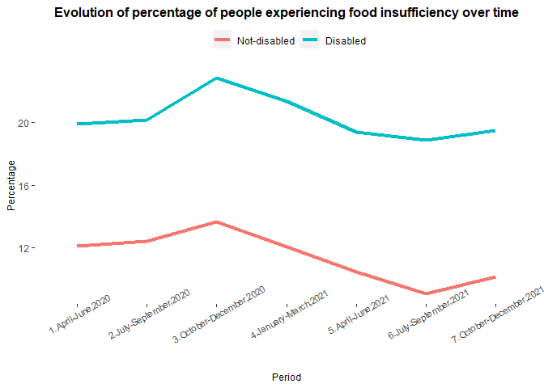

```r
#### Without error bars, Weighted
data.18.65 %>% group_by(Period,MDCR.DIS) %>%
  summarise(count=n(),w.mean.food_insuf=weighted.mean(food_insuf,PWEIGHT)) %>%
  ggplot(aes(group=factor(MDCR.DIS),fill=factor(MDCR.DIS),color=factor(MDCR.DIS), y=w.mean.food_insuf , x=factor(Period))) +
  geom_line(size=1.5)+
  labs(title ="Evolution of percentage of people experiencing food insufficiency over time",y="Percentage",x="Period")+
  theme(axis.text.x = element_text(size=8, angle=30),
        panel.background=element_blank(),
        plot.title    = element_text(face = "bold",   size = 12, hjust = 0.5),
        axis.text.y   = element_text(size=9),
        axis.title.x   = element_text(size=9),
        axis.title.y  = element_text(size=9),
        legend.text   = element_text(size=9),
        legend.title  = element_blank(),
        legend.position = "top")
```

### Regression Findings

```r
##without controls
food.data.18.65.m1<-feols(food_insuf~MDCR.DIS*Period,data=data.18.65,cluster = ~ state_fips,weights = data.18.65$PWEIGHT)
etable(food.data.18.65.m1)
```

```
##                                                  food.data.18.65.m1
## Dependent Var.:                                          food_insuf
##
## (Intercept)                                       12.14*** (0.4087)
## MDCR.DISDisabled                                  7.751*** (0.9192)
## Period2.July-September,2020                         0.3089 (0.1938)
## Period3.October-December,2020                     1.547*** (0.2733)
## Period4.January-March,2021                         -0.0542 (0.1817)
## Period5.April-June,2021                          -1.646*** (0.2164)
## Period6.July-September,2021                      -3.048*** (0.2093)
## Period7.October-December,2021                    -1.955*** (0.3463)
## MDCR.DISDisabled x Period2.July-September,2020      -0.0498 (1.269)
## MDCR.DISDisabled x Period3.October-December,2020      1.402 (1.314)
## MDCR.DISDisabled x Period4.January-March,2021         1.520 (1.448)
## MDCR.DISDisabled x Period5.April-June,2021           1.142 (0.9338)
## MDCR.DISDisabled x Period6.July-September,2021      2.049* (0.9240)
## MDCR.DISDisabled x Period7.October-December,2021      1.555 (1.800)
## ________________________________________         __________________
## S.E.: Clustered                                      by: state_fips
## Observations                                              1,729,108
## R2                                                          0.00596
## Adj. R2                                                     0.00595
## ---
## Signif. codes: 0 '***' 0.001 '**' 0.01 '*' 0.05 '.' 0.1 ' ' 1
```

```r
round(confint(food.data.18.65.m1),digits=2)
```

```
##                                                2.5 % 97.5 %
## (Intercept)                                    11.31  12.96
## MDCR.DISDisabled                                5.91   9.60
## Period2.July-September,2020                    -0.08   0.70
## Period3.October-December,2020                   1.00   2.10
## Period4.January-March,2021                     -0.42   0.31
## Period5.April-June,2021                        -2.08  -1.21
## Period6.July-September,2021                    -3.47  -2.63
## Period7.October-December,2021                  -2.65  -1.26
## MDCR.DISDisabled:Period2.July-September,2020   -2.60   2.50
## MDCR.DISDisabled:Period3.October-December,2020 -1.24   4.04
## MDCR.DISDisabled:Period4.January-March,2021    -1.39   4.43
## MDCR.DISDisabled:Period5.April-June,2021       -0.73   3.02
## MDCR.DISDisabled:Period6.July-September,2021    0.19   3.90
## MDCR.DISDisabled:Period7.October-December,2021 -2.06   5.17
```

```r
##with controls
food.data.18.65.m2<-feols(food_insuf~MDCR.DIS*Period+factor(state_fips)+factor(EGENDER)+factor(INCOME)+factor(RRACE)+factor(RHISPANIC)+AGE+factor(TENURE)+factor(MS)+factor(EEDUC)+factor(THHLD_NUMKID)+factor(THHLD_NUMPER),
                          data=data.18.65,cluster = ~ state_fips ,weights = data.18.65$PWEIGHT)
etable(food.data.18.65.m2)
```

```
##                                                   food.data.18.65.m2
## Dependent Var.:                                           food_insuf
##
## (Intercept)                                         22.37*** (1.165)
## MDCR.DISDisabled                                      1.248 (0.8919)
## Period2.July-September,2020                       0.7739*** (0.1943)
## Period3.October-December,2020                      2.700*** (0.2701)
## Period4.January-March,2021                         1.114*** (0.1880)
## Period5.April-June,2021                             -0.2459 (0.2153)
## Period6.July-September,2021                       -1.656*** (0.1934)
## Period7.October-December,2021                      -0.7525* (0.2895)
## factor(state_fips)2                               -2.068*** (0.1163)
## factor(state_fips)4                               -1.870*** (0.1262)
## factor(state_fips)5                                0.1310** (0.0440)
## factor(state_fips)6                               -2.115*** (0.1438)
## factor(state_fips)8                               -1.234*** (0.1178)
## factor(state_fips)9                               0.5021*** (0.0905)
## factor(state_fips)10                             -0.8632*** (0.0491)
## factor(state_fips)11                             -0.5620*** (0.1069)
## factor(state_fips)12                                 0.1268 (0.0814)
## factor(state_fips)13                             -0.7004*** (0.0339)
## factor(state_fips)15                              -3.165*** (0.2598)
## factor(state_fips)16                              -2.502*** (0.1000)
## factor(state_fips)17                             -0.8024*** (0.0746)
## factor(state_fips)18                              -0.1853** (0.0675)
## factor(state_fips)19                             -0.8784*** (0.0923)
## factor(state_fips)20                              -1.292*** (0.0930)
## factor(state_fips)21                              0.4867*** (0.0704)
## factor(state_fips)22                               1.367*** (0.0179)
## factor(state_fips)23                              -1.926*** (0.0957)
## factor(state_fips)24                                 0.0211 (0.0552)
## factor(state_fips)25                              -1.502*** (0.1006)
## factor(state_fips)26                             -0.6973*** (0.0540)
## factor(state_fips)27                              -2.061*** (0.1049)
## factor(state_fips)28                               1.107*** (0.0463)
## factor(state_fips)29                             -0.7007*** (0.0620)
## factor(state_fips)30                              -2.335*** (0.1000)
## factor(state_fips)31                             -0.6552*** (0.0953)
## factor(state_fips)32                             -0.8435*** (0.1067)
## factor(state_fips)33                              -1.051*** (0.1134)
```

[output cut: 64 more lines]

```
## factor(THHLD_NUMPER)9                              8.044*** (0.8655)
## factor(THHLD_NUMPER)10                              10.40*** (1.129)
## MDCR.DISDisabled x Period2.July-September,2020       -0.5647 (1.131)
## MDCR.DISDisabled x Period3.October-December,2020       1.687 (1.310)
## MDCR.DISDisabled x Period4.January-March,2021          1.518 (1.265)
## MDCR.DISDisabled x Period5.April-June,2021           0.7519 (0.9736)
## MDCR.DISDisabled x Period6.July-September,2021       1.845* (0.8619)
## MDCR.DISDisabled x Period7.October-December,2021       1.539 (1.560)
## ________________________________________         ___________________
## S.E.: Clustered                                       by: state_fips
## Observations                                               1,729,108
## R2                                                           0.12813
## Adj. R2                                                      0.12808
## ---
## Signif. codes: 0 '***' 0.001 '**' 0.01 '*' 0.05 '.' 0.1 ' ' 1
```

```r
round(confint(food.data.18.65.m2),digits=2)
```

```
##                                                 2.5 % 97.5 %
## (Intercept)                                     20.03  24.71
## MDCR.DISDisabled                                -0.54   3.04
## Period2.July-September,2020                      0.38   1.16
## Period3.October-December,2020                    2.16   3.24
## Period4.January-March,2021                       0.74   1.49
## Period5.April-June,2021                         -0.68   0.19
## Period6.July-September,2021                     -2.04  -1.27
## Period7.October-December,2021                   -1.33  -0.17
## factor(state_fips)2                             -2.30  -1.83
## factor(state_fips)4                             -2.12  -1.62
## factor(state_fips)5                              0.04   0.22
## factor(state_fips)6                             -2.40  -1.83
## factor(state_fips)8                             -1.47  -1.00
## factor(state_fips)9                              0.32   0.68
## factor(state_fips)10                            -0.96  -0.76
## factor(state_fips)11                            -0.78  -0.35
## factor(state_fips)12                            -0.04   0.29
## factor(state_fips)13                            -0.77  -0.63
## factor(state_fips)15                            -3.69  -2.64
## factor(state_fips)16                            -2.70  -2.30
## factor(state_fips)17                            -0.95  -0.65
## factor(state_fips)18                            -0.32  -0.05
## factor(state_fips)19                            -1.06  -0.69
## factor(state_fips)20                            -1.48  -1.10
## factor(state_fips)21                             0.35   0.63
## factor(state_fips)22                             1.33   1.40
## factor(state_fips)23                            -2.12  -1.73
## factor(state_fips)24                            -0.09   0.13
## factor(state_fips)25                            -1.70  -1.30
## factor(state_fips)26                            -0.81  -0.59
## factor(state_fips)27                            -2.27  -1.85
## factor(state_fips)28                             1.01   1.20
## factor(state_fips)29                            -0.83  -0.58
## factor(state_fips)30                            -2.54  -2.13
## factor(state_fips)31                            -0.85  -0.46
## factor(state_fips)32                            -1.06  -0.63
## factor(state_fips)33                            -1.28  -0.82
## factor(state_fips)34                            -0.71  -0.32
## factor(state_fips)35                            -2.06  -1.39
```

[output cut: 55 more lines]

```
## factor(THHLD_NUMPER)2                            0.57   1.72
## factor(THHLD_NUMPER)3                            1.51   2.57
## factor(THHLD_NUMPER)4                            1.95   3.51
## factor(THHLD_NUMPER)5                            2.72   4.01
## factor(THHLD_NUMPER)6                            3.86   5.87
## factor(THHLD_NUMPER)7                            4.37   6.81
## factor(THHLD_NUMPER)8                            5.26   9.44
## factor(THHLD_NUMPER)9                            6.31   9.78
## factor(THHLD_NUMPER)10                           8.14  12.67
## MDCR.DISDisabled:Period2.July-September,2020    -2.84   1.71
## MDCR.DISDisabled:Period3.October-December,2020  -0.95   4.32
## MDCR.DISDisabled:Period4.January-March,2021     -1.02   4.06
## MDCR.DISDisabled:Period5.April-June,2021        -1.20   2.71
## MDCR.DISDisabled:Period6.July-September,2021     0.11   3.58
## MDCR.DISDisabled:Period7.October-December,2021  -1.59   4.67
```

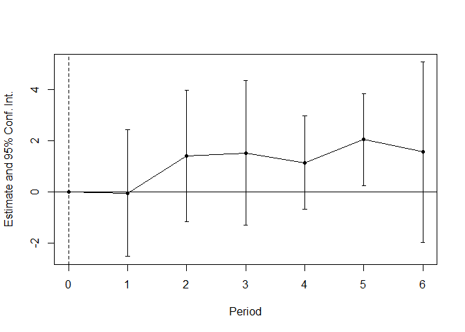

```r
##coefficient plots
data.18.65$Period.num<-as.integer(data.18.65$Period)
data.18.65$PeriodN<-(data.18.65$Period.num)-1
data.18.65$state_fips<-as.factor(data.18.65$state_fips)
data.18.65$treated<-ifelse(data.18.65$MDCR.DIS=="Disabled",1,0)


##without controls
es.food.data.18.65.m1 <-
  feols(food_insuf ~ i(PeriodN, ref = 0):treated+factor(MDCR.DIS)+factor(PeriodN),
        cluster = ~ state_fips,
        data = data.18.65,
        weights = data.18.65$PWEIGHT)

iplot(es.food.data.18.65.m1,main=" ",grid=FALSE,xlab="Period",ref.line = TRUE, pt.join = TRUE)
```

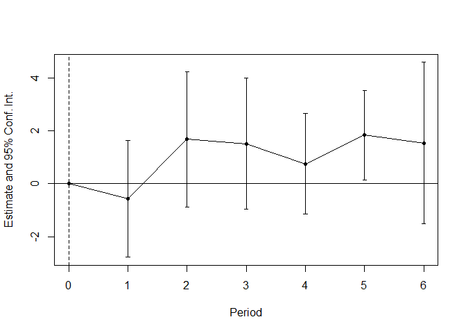

```r
##with controls
es.food.data.18.65.m2 <-
  feols(food_insuf ~ i(PeriodN, ref = 0):treated+factor(MDCR.DIS)+factor(PeriodN)+factor(state_fips)+factor(EGENDER)+factor(INCOME)+factor(RRACE)+factor(RHISPANIC)+AGE+factor(TENURE)+factor(MS)+factor(EEDUC)+factor(THHLD_NUMKID)+factor(THHLD_NUMPER),
        cluster = ~ state_fips,
        data = data.18.65,
        weights = data.18.65$PWEIGHT)

iplot(es.food.data.18.65.m2,main=" ",grid=FALSE,xlab="Period",ref.line = TRUE, pt.join = TRUE)
```

## Mortgage/Rent Confidence

### Preparing the analytical sample

```r
load("hps_data_mortconf.RData")

###Age variable
data.mortconf$AGE<-2022-data.mortconf$TBIRTH_YEAR

###MORTCONF variable is asked only for TENURE==2 and TENURE==3 respondents
data.mortconf<-data.mortconf %>% filter(TENURE==2|TENURE==3,)

###Create Period
data.mortconf<- data.mortconf %>% filter(WEEK<=40,)

data.mortconf$Period <- as.factor(ifelse(data.mortconf$WEEK >=1 & data.mortconf$WEEK <=9, '1.April-June,2020',
                                         ifelse(data.mortconf$WEEK >=10 & data.mortconf$WEEK <=15, '2.July-September,2020',
                                                ifelse(data.mortconf$WEEK >=16 & data.mortconf$WEEK <=21, '3.October-December,2020',
                                                       ifelse(data.mortconf$WEEK >=22 & data.mortconf$WEEK <=27, '4.January-March,2021',
                                                              ifelse(data.mortconf$WEEK >=28 & data.mortconf$WEEK <=33, '5.April-June,2021',
                                                                     ifelse(data.mortconf$WEEK >=34 & data.mortconf$WEEK <=38, '6.July-September,2021','7.October-December,2021')))))))




#################### Target Population #####################

##Disabled Identification

#Selecting people aged 18-64 and those who responded to the Medicare question
data.mortconf.18.65<-data.mortconf %>% filter(AGE>=18 & AGE<=64 & HLTHINS3>=0,)

##Creating a disability dummy
data.mortconf.18.65$MDCR.DIS<-ifelse(data.mortconf.18.65$HLTHINS3==1,"Disabled","Not-disabled")
table(data.mortconf.18.65$MDCR.DIS,exclude=NULL)
```

```
##
##     Disabled Not-disabled
##        67381      1333227
```

```r
##Releveling to make the non-disabled the reference category
data.mortconf.18.65$MDCR.DIS<-relevel(factor(data.mortconf.18.65$MDCR.DIS),ref="Not-disabled")

##Creating mortgage/rent hardship dummy
table(data.mortconf.18.65$MORTCONF,exclude = NULL)
```

```
##
##    -99    -88      1      2      3      4      5
##   1063   4196  76109 122957 241937 933116  21230
```

```r
data.mortconf.18.65<-data.mortconf.18.65 %>% filter(MORTCONF>=0,)
data.mortconf.18.65$mort_conf<-ifelse(data.mortconf.18.65$MORTCONF==1|data.mortconf.18.65$MORTCONF==2,1,0)

##Multiplying food insufficiency by 100 to create percentages
data.mortconf.18.65$mort_conf<-data.mortconf.18.65$mort_conf*100
table(data.mortconf.18.65$mort_conf,exclude = NULL)
```

```
##
##       0     100
## 1196283  199066
```

### Descriptive Findings

```r
##Overall Sample
table1(~ factor(mort_conf)+factor(EGENDER)+factor(RRACE)+factor(INCOME)+factor(RHISPANIC)+AGE+factor(TENURE)+factor(MS)+factor(EEDUC)+THHLD_NUMKID+THHLD_NUMPER| MDCR.DIS, data.mortconf.18.65,overall = FALSE)
```

|  | Not-disabled (N=1328340) | Disabled (N=67009) |
| --- | --- | --- |
| factor(mort_conf) |  |  |
| 0 | 1144246 (86.1%) | 52037 (77.7%) |
| 100 | 184094 (13.9%) | 14972 (22.3%) |
| factor(EGENDER) |  |  |
| 1 | 508181 (38.3%) | 21337 (31.8%) |
| 2 | 820159 (61.7%) | 45672 (68.2%) |
| factor(RRACE) |  |  |
| 1 | 1071646 (80.7%) | 49701 (74.2%) |
| 2 | 112719 (8.5%) | 9073 (13.5%) |
| 3 | 70699 (5.3%) | 3138 (4.7%) |
| 4 | 73276 (5.5%) | 5097 (7.6%) |
| factor(INCOME) |  |  |
| -99 | 16868 (1.3%) | 977 (1.5%) |
| -88 | 35227 (2.7%) | 1746 (2.6%) |
| 1 | 113891 (8.6%) | 22663 (33.8%) |
| 2 | 97758 (7.4%) | 8701 (13.0%) |
| 3 | 127673 (9.6%) | 7636 (11.4%) |
| 4 | 216019 (16.3%) | 9803 (14.6%) |
| 5 | 189542 (14.3%) | 5917 (8.8%) |
| 6 | 257573 (19.4%) | 5669 (8.5%) |
| 7 | 128380 (9.7%) | 2166 (3.2%) |
| 8 | 145409 (10.9%) | 1731 (2.6%) |
| factor(RHISPANIC) |  |  |
| 1 | 1188438 (89.5%) | 59403 (88.6%) |
| 2 | 139902 (10.5%) | 7606 (11.4%) |
| AGE |  |  |
| Mean (SD) | 44.6 (10.8) | 52.5 (9.82) |
| Median [Min, Max] | 44.0 [19.0, 64.0] | 55.0 [19.0, 64.0] |
| factor(TENURE) |  |  |
| 2 | 869884 (65.5%) | 36224 (54.1%) |
| 3 | 458456 (34.5%) | 30785 (45.9%) |
| factor(MS) |  |  |
| -99 | 4002 (0.3%) | 417 (0.6%) |
| 1 | 768626 (57.9%) | 29862 (44.6%) |
| 2 | 16833 (1.3%) | 2967 (4.4%) |
| 3 | 175501 (13.2%) | 15988 (23.9%) |
| 4 | 27578 (2.1%) | 2507 (3.7%) |
| 5 | 335800 (25.3%) | 15268 (22.8%) |
| factor(EEDUC) |  |  |
| 1 | 6697 (0.5%) | 962 (1.4%) |
| 2 | 17340 (1.3%) | 2188 (3.3%) |
| 3 | 134054 (10.1%) | 13018 (19.4%) |
| 4 | 274401 (20.7%) | 20585 (30.7%) |
| 5 | 139188 (10.5%) | 9770 (14.6%) |
| 6 | 422921 (31.8%) | 12669 (18.9%) |
| 7 | 333739 (25.1%) | 7817 (11.7%) |
| THHLD_NUMKID |  |  |
| Mean (SD) | 0.912 (1.16) | 0.588 (1.02) |
| Median [Min, Max] | 0 [0, 5.00] | 0 [0, 5.00] |
| THHLD_NUMPER |  |  |
| Mean (SD) | 3.08 (1.53) | 2.92 (1.72) |
| Median [Min, Max] | 3.00 [1.00, 10.0] | 2.00 [1.00, 10.0] |

```r
##Every Period
table1(~ factor(mort_conf)+factor(EGENDER)+factor(RRACE)+factor(INCOME)+factor(RHISPANIC)+AGE+factor(TENURE)+factor(MS)+factor(EEDUC)+THHLD_NUMKID+THHLD_NUMPER| Period:MDCR.DIS, data.mortconf.18.65,overall = FALSE)
```

|  | 1.April-June,2020 Not-disabled (N=371944) | 1.April-June,2020 Disabled (N=19122) | 2.July-September,2020 Not-disabled (N=258808) | 2.July-September,2020 Disabled (N=12641) | 3.October-December,2020 Not-disabled (N=187516) | 3.October-December,2020 Disabled (N=9025) | 4.January-March,2021 Not-disabled (N=170373) | 4.January-March,2021 Disabled (N=8475) | 5.April-June,2021 Not-disabled (N=159434) | 5.April-June,2021 Disabled (N=8122) | 6.July-September,2021 Not-disabled (N=131724) | 6.July-September,2021 Disabled (N=7060) | 7.October-December,2021 Not-disabled (N=48541) | 7.October-December,2021 Disabled (N=2564) |
| --- | --- | --- | --- | --- | --- | --- | --- | --- | --- | --- | --- | --- | --- | --- |
| factor(mort_conf) |  |  |  |  |  |  |  |  |  |  |  |  |  |  |
| 0 | 316746 (85.2%) | 14869 (77.8%) | 220388 (85.2%) | 9760 (77.2%) | 160482 (85.6%) | 6903 (76.5%) | 147325 (86.5%) | 6540 (77.2%) | 141279 (88.6%) | 6498 (80.0%) | 115541 (87.7%) | 5504 (78.0%) | 42485 (87.5%) | 1963 (76.6%) |
| 100 | 55198 (14.8%) | 4253 (22.2%) | 38420 (14.8%) | 2881 (22.8%) | 27034 (14.4%) | 2122 (23.5%) | 23048 (13.5%) | 1935 (22.8%) | 18155 (11.4%) | 1624 (20.0%) | 16183 (12.3%) | 1556 (22.0%) | 6056 (12.5%) | 601 (23.4%) |
| factor(EGENDER) |  |  |  |  |  |  |  |  |  |  |  |  |  |  |
| 1 | 141880 (38.1%) | 6136 (32.1%) | 100687 (38.9%) | 4022 (31.8%) | 71491 (38.1%) | 2882 (31.9%) | 63654 (37.4%) | 2697 (31.8%) | 61209 (38.4%) | 2596 (32.0%) | 49922 (37.9%) | 2175 (30.8%) | 19338 (39.8%) | 829 (32.3%) |
| 2 | 230064 (61.9%) | 12986 (67.9%) | 158121 (61.1%) | 8619 (68.2%) | 116025 (61.9%) | 6143 (68.1%) | 106719 (62.6%) | 5778 (68.2%) | 98225 (61.6%) | 5526 (68.0%) | 81802 (62.1%) | 4885 (69.2%) | 29203 (60.2%) | 1735 (67.7%) |
| factor(RRACE) |  |  |  |  |  |  |  |  |  |  |  |  |  |  |
| 1 | 298650 (80.3%) | 14007 (73.3%) | 207945 (80.3%) | 9233 (73.0%) | 153112 (81.7%) | 6814 (75.5%) | 137968 (81.0%) | 6319 (74.6%) | 128322 (80.5%) | 6048 (74.5%) | 106375 (80.8%) | 5311 (75.2%) | 39274 (80.9%) | 1969 (76.8%) |
| 2 | 33936 (9.1%) | 2735 (14.3%) | 22568 (8.7%) | 1757 (13.9%) | 14395 (7.7%) | 1118 (12.4%) | 13723 (8.1%) | 1083 (12.8%) | 13205 (8.3%) | 1103 (13.6%) | 11042 (8.4%) | 969 (13.7%) | 3850 (7.9%) | 308 (12.0%) |
| 3 | 19073 (5.1%) | 949 (5.0%) | 13412 (5.2%) | 633 (5.0%) | 9486 (5.1%) | 383 (4.2%) | 9241 (5.4%) | 419 (4.9%) | 9348 (5.9%) | 387 (4.8%) | 7307 (5.5%) | 282 (4.0%) | 2832 (5.8%) | 85 (3.3%) |
| 4 | 20285 (5.5%) | 1431 (7.5%) | 14883 (5.8%) | 1018 (8.1%) | 10523 (5.6%) | 710 (7.9%) | 9441 (5.5%) | 654 (7.7%) | 8559 (5.4%) | 584 (7.2%) | 7000 (5.3%) | 498 (7.1%) | 2585 (5.3%) | 202 (7.9%) |
| factor(INCOME) |  |  |  |  |  |  |  |  |  |  |  |  |  |  |
| -99 | 3387 (0.9%) | 197 (1.0%) | 3252 (1.3%) | 190 (1.5%) | 2693 (1.4%) | 158 (1.8%) | 2557 (1.5%) | 141 (1.7%) | 2503 (1.6%) | 140 (1.7%) | 1864 (1.4%) | 124 (1.8%) | 612 (1.3%) | 27 (1.1%) |
| -88 | 5940 (1.6%) | 321 (1.7%) | 6380 (2.5%) | 311 (2.5%) | 5764 (3.1%) | 254 (2.8%) | 5371 (3.2%) | 247 (2.9%) | 5750 (3.6%) | 285 (3.5%) | 4518 (3.4%) | 246 (3.5%) | 1504 (3.1%) | 82 (3.2%) |
| 1 | 34440 (9.3%) | 6489 (33.9%) | 22726 (8.8%) | 4143 (32.8%) | 14739 (7.9%) | 2927 (32.4%) | 13680 (8.0%) | 2802 (33.1%) | 12752 (8.0%) | 2897 (35.7%) | 11062 (8.4%) | 2408 (34.1%) | 4492 (9.3%) | 997 (38.9%) |
| 2 | 28909 (7.8%) | 2481 (13.0%) | 19615 (7.6%) | 1666 (13.2%) | 13186 (7.0%) | 1191 (13.2%) | 12064 (7.1%) | 1054 (12.4%) | 11030 (6.9%) | 1056 (13.0%) | 9271 (7.0%) | 913 (12.9%) | 3683 (7.6%) | 340 (13.3%) |
| 3 | 37306 (10.0%) | 2225 (11.6%) | 25694 (9.9%) | 1471 (11.6%) | 17704 (9.4%) | 973 (10.8%) | 16322 (9.6%) | 1012 (11.9%) | 14137 (8.9%) | 877 (10.8%) | 11926 (9.1%) | 827 (11.7%) | 4584 (9.4%) | 251 (9.8%) |
| 4 | 62811 (16.9%) | 2891 (15.1%) | 42714 (16.5%) | 1895 (15.0%) | 29956 (16.0%) | 1338 (14.8%) | 27900 (16.4%) | 1265 (14.9%) | 24706 (15.5%) | 1140 (14.0%) | 20242 (15.4%) | 944 (13.4%) | 7690 (15.8%) | 330 (12.9%) |
| 5 | 53930 (14.5%) | 1737 (9.1%) | 37425 (14.5%) | 1108 (8.8%) | 26958 (14.4%) | 821 (9.1%) | 24179 (14.2%) | 749 (8.8%) | 22153 (13.9%) | 655 (8.1%) | 18163 (13.8%) | 627 (8.9%) | 6734 (13.9%) | 220 (8.6%) |
| 6 | 71724 (19.3%) | 1661 (8.7%) | 49636 (19.2%) | 1086 (8.6%) | 36995 (19.7%) | 793 (8.8%) | 32984 (19.4%) | 722 (8.5%) | 31361 (19.7%) | 635 (7.8%) | 25756 (19.6%) | 580 (8.2%) | 9117 (18.8%) | 192 (7.5%) |
| 7 | 35079 (9.4%) | 633 (3.3%) | 24085 (9.3%) | 450 (3.6%) | 18570 (9.9%) | 316 (3.5%) | 16481 (9.7%) | 262 (3.1%) | 16141 (10.1%) | 239 (2.9%) | 13352 (10.1%) | 208 (2.9%) | 4672 (9.6%) | 58 (2.3%) |
| 8 | 38418 (10.3%) | 487 (2.5%) | 27281 (10.5%) | 321 (2.5%) | 20951 (11.2%) | 254 (2.8%) | 18835 (11.1%) | 221 (2.6%) | 18901 (11.9%) | 198 (2.4%) | 15570 (11.8%) | 183 (2.6%) | 5453 (11.2%) | 67 (2.6%) |
| factor(RHISPANIC) |  |  |  |  |  |  |  |  |  |  |  |  |  |  |
| 1 | 334005 (89.8%) | 17065 (89.2%) | 231288 (89.4%) | 11059 (87.5%) | 168747 (90.0%) | 8061 (89.3%) | 151000 (88.6%) | 7424 (87.6%) | 142421 (89.3%) | 7177 (88.4%) | 117545 (89.2%) | 6325 (89.6%) | 43432 (89.5%) | 2292 (89.4%) |
| 2 | 37939 (10.2%) | 2057 (10.8%) | 27520 (10.6%) | 1582 (12.5%) | 18769 (10.0%) | 964 (10.7%) | 19373 (11.4%) | 1051 (12.4%) | 17013 (10.7%) | 945 (11.6%) | 14179 (10.8%) | 735 (10.4%) | 5109 (10.5%) | 272 (10.6%) |
| AGE |  |  |  |  |  |  |  |  |  |  |  |  |  |  |
| Mean (SD) | 44.4 (10.6) | 52.1 (9.87) | 44.3 (10.8) | 52.1 (10.1) | 44.4 (10.7) | 52.4 (9.88) | 45.0 (10.9) | 52.9 (9.65) | 45.3 (10.8) | 53.1 (9.56) | 44.7 (11.0) | 53.2 (9.65) | 44.0 (11.3) | 53.5 (9.57) |
| Median [Min, Max] | 44.0 [20.0, 64.0] | 54.0 [20.0, 64.0] | 44.0 [20.0, 64.0] | 55.0 [20.0, 64.0] | 44.0 [20.0, 64.0] | 55.0 [20.0, 64.0] | 45.0 [19.0, 64.0] | 56.0 [19.0, 64.0] | 45.0 [19.0, 64.0] | 56.0 [19.0, 64.0] | 44.0 [19.0, 64.0] | 56.0 [19.0, 64.0] | 44.0 [19.0, 64.0] | 57.0 [19.0, 64.0] |
| factor(TENURE) |  |  |  |  |  |  |  |  |  |  |  |  |  |  |
| 2 | 238286 (64.1%) | 10347 (54.1%) | 167543 (64.7%) | 6855 (54.2%) | 123409 (65.8%) | 4873 (54.0%) | 114309 (67.1%) | 4702 (55.5%) | 106765 (67.0%) | 4292 (52.8%) | 88493 (67.2%) | 3887 (55.1%) | 31079 (64.0%) | 1268 (49.5%) |
| 3 | 133658 (35.9%) | 8775 (45.9%) | 91265 (35.3%) | 5786 (45.8%) | 64107 (34.2%) | 4152 (46.0%) | 56064 (32.9%) | 3773 (44.5%) | 52669 (33.0%) | 3830 (47.2%) | 43231 (32.8%) | 3173 (44.9%) | 17462 (36.0%) | 1296 (50.5%) |
| factor(MS) |  |  |  |  |  |  |  |  |  |  |  |  |  |  |
| -99 | 888 (0.2%) | 92 (0.5%) | 796 (0.3%) | 81 (0.6%) | 607 (0.3%) | 52 (0.6%) | 632 (0.4%) | 59 (0.7%) | 558 (0.4%) | 80 (1.0%) | 400 (0.3%) | 35 (0.5%) | 121 (0.2%) | 18 (0.7%) |
| 1 | 213524 (57.4%) | 8594 (44.9%) | 148650 (57.4%) | 5722 (45.3%) | 109382 (58.3%) | 4029 (44.6%) | 99408 (58.3%) | 3787 (44.7%) | 93797 (58.8%) | 3422 (42.1%) | 76608 (58.2%) | 3232 (45.8%) | 27257 (56.2%) | 1076 (42.0%) |
| 2 | 4384 (1.2%) | 754 (3.9%) | 3039 (1.2%) | 519 (4.1%) | 2250 (1.2%) | 425 (4.7%) | 2343 (1.4%) | 410 (4.8%) | 2239 (1.4%) | 376 (4.6%) | 1869 (1.4%) | 334 (4.7%) | 709 (1.5%) | 149 (5.8%) |
| 3 | 49493 (13.3%) | 4513 (23.6%) | 33713 (13.0%) | 2952 (23.4%) | 24511 (13.1%) | 2128 (23.6%) | 22569 (13.2%) | 2019 (23.8%) | 21306 (13.4%) | 2064 (25.4%) | 17483 (13.3%) | 1656 (23.5%) | 6426 (13.2%) | 656 (25.6%) |
| 4 | 8068 (2.2%) | 741 (3.9%) | 5586 (2.2%) | 471 (3.7%) | 3754 (2.0%) | 332 (3.7%) | 3448 (2.0%) | 290 (3.4%) | 3232 (2.0%) | 300 (3.7%) | 2587 (2.0%) | 269 (3.8%) | 903 (1.9%) | 104 (4.1%) |
| 5 | 95587 (25.7%) | 4428 (23.2%) | 67024 (25.9%) | 2896 (22.9%) | 47012 (25.1%) | 2059 (22.8%) | 41973 (24.6%) | 1910 (22.5%) | 38302 (24.0%) | 1880 (23.1%) | 32777 (24.9%) | 1534 (21.7%) | 13125 (27.0%) | 561 (21.9%) |
| factor(EEDUC) |  |  |  |  |  |  |  |  |  |  |  |  |  |  |
| 1 | 1964 (0.5%) | 257 (1.3%) | 1396 (0.5%) | 204 (1.6%) | 832 (0.4%) | 111 (1.2%) | 885 (0.5%) | 122 (1.4%) | 767 (0.5%) | 108 (1.3%) | 590 (0.4%) | 112 (1.6%) | 263 (0.5%) | 48 (1.9%) |
| 2 | 5457 (1.5%) | 697 (3.6%) | 3569 (1.4%) | 463 (3.7%) | 2165 (1.2%) | 251 (2.8%) | 2204 (1.3%) | 253 (3.0%) | 1906 (1.2%) | 246 (3.0%) | 1441 (1.1%) | 212 (3.0%) | 598 (1.2%) | 66 (2.6%) |
| 3 | 40144 (10.8%) | 3752 (19.6%) | 27380 (10.6%) | 2454 (19.4%) | 17944 (9.6%) | 1699 (18.8%) | 16292 (9.6%) | 1608 (19.0%) | 15074 (9.5%) | 1548 (19.1%) | 12576 (9.5%) | 1412 (20.0%) | 4644 (9.6%) | 545 (21.3%) |
| 4 | 77863 (20.9%) | 5954 (31.1%) | 54251 (21.0%) | 3832 (30.3%) | 38869 (20.7%) | 2732 (30.3%) | 35133 (20.6%) | 2594 (30.6%) | 31569 (19.8%) | 2504 (30.8%) | 27048 (20.5%) | 2133 (30.2%) | 9668 (19.9%) | 836 (32.6%) |
| 5 | 38773 (10.4%) | 2762 (14.4%) | 27128 (10.5%) | 1797 (14.2%) | 20027 (10.7%) | 1383 (15.3%) | 18242 (10.7%) | 1227 (14.5%) | 16226 (10.2%) | 1218 (15.0%) | 13833 (10.5%) | 1006 (14.2%) | 4959 (10.2%) | 377 (14.7%) |
| 6 | 116843 (31.4%) | 3485 (18.2%) | 81864 (31.6%) | 2419 (19.1%) | 60886 (32.5%) | 1818 (20.1%) | 54515 (32.0%) | 1638 (19.3%) | 51265 (32.2%) | 1553 (19.1%) | 41923 (31.8%) | 1315 (18.6%) | 15625 (32.2%) | 441 (17.2%) |
| 7 | 90900 (24.4%) | 2215 (11.6%) | 63220 (24.4%) | 1472 (11.6%) | 46793 (25.0%) | 1031 (11.4%) | 43102 (25.3%) | 1033 (12.2%) | 42627 (26.7%) | 945 (11.6%) | 34313 (26.0%) | 870 (12.3%) | 12784 (26.3%) | 251 (9.8%) |
| THHLD_NUMKID |  |  |  |  |  |  |  |  |  |  |  |  |  |  |
| Mean (SD) | 0.952 (1.18) | 0.644 (1.06) | 0.938 (1.17) | 0.631 (1.04) | 0.929 (1.17) | 0.605 (1.03) | 0.885 (1.14) | 0.550 (0.978) | 0.862 (1.13) | 0.521 (0.954) | 0.852 (1.13) | 0.502 (0.967) | 0.809 (1.12) | 0.466 (0.905) |
| Median [Min, Max] | 0 [0, 5.00] | 0 [0, 5.00] | 0 [0, 5.00] | 0 [0, 5.00] | 0 [0, 5.00] | 0 [0, 5.00] | 0 [0, 5.00] | 0 [0, 5.00] | 0 [0, 5.00] | 0 [0, 5.00] | 0 [0, 5.00] | 0 [0, 5.00] | 0 [0, 5.00] | 0 [0, 5.00] |
| THHLD_NUMPER |  |  |  |  |  |  |  |  |  |  |  |  |  |  |
| Mean (SD) | 3.13 (1.57) | 3.04 (1.80) | 3.11 (1.54) | 3.01 (1.75) | 3.08 (1.52) | 2.92 (1.67) | 3.06 (1.51) | 2.86 (1.68) | 3.02 (1.49) | 2.78 (1.63) | 3.02 (1.50) | 2.80 (1.64) | 2.91 (1.49) | 2.63 (1.61) |
| Median [Min, Max] | 3.00 [1.00, 10.0] | 3.00 [1.00, 10.0] | 3.00 [1.00, 10.0] | 3.00 [1.00, 10.0] | 3.00 [1.00, 10.0] | 2.00 [1.00, 10.0] | 3.00 [1.00, 10.0] | 2.00 [1.00, 10.0] | 3.00 [1.00, 10.0] | 2.00 [1.00, 10.0] | 3.00 [1.00, 10.0] | 2.00 [1.00, 10.0] | 3.00 [1.00, 10.0] | 2.00 [1.00, 10.0] |

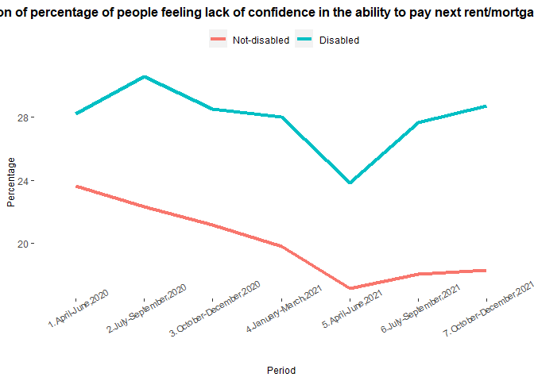

```r
#### Without error bars, Weighted
data.mortconf.18.65 %>% group_by(Period,MDCR.DIS) %>%
  summarise(count=n(),w.mean.mort_conf=weighted.mean(mort_conf,PWEIGHT)) %>%
  ggplot(aes(group=factor(MDCR.DIS),fill=factor(MDCR.DIS),color=factor(MDCR.DIS), y=w.mean.mort_conf , x=factor(Period))) +
  geom_line(size=1.5)+
  labs(title ="Evolution of percentage of people feeling lack of confidence in the ability to pay next rent/mortgage over time",y="Percentage",x="Period")+
  theme(axis.text.x = element_text(size=8, angle=30),
        panel.background=element_blank(),
        plot.title    = element_text(face = "bold",   size = 12, hjust = 0.5),
        axis.text.y   = element_text(size=9),
        axis.title.x   = element_text(size=9),
        axis.title.y  = element_text(size=9),
        legend.text   = element_text(size=9),
        legend.title  = element_blank(),
        legend.position = "top")
```

### Regression Findings

```r
################################### Regression #####################################

##without controls
food.data.mortconf.18.65.m1<-feols(mort_conf~MDCR.DIS*Period,data=data.mortconf.18.65,cluster = ~ state_fips)#,weights = data.mortconf.18.65$PWEIGHT)
etable(food.data.mortconf.18.65.m1)
```

```
##                                                  food.data.mortco..
## Dependent Var.:                                           mort_conf
##
## (Intercept)                                       14.84*** (0.5751)
## MDCR.DISDisabled                                  7.401*** (0.5119)
## Period2.July-September,2020                         0.0046 (0.1332)
## Period3.October-December,2020                      -0.4235 (0.2637)
## Period4.January-March,2021                       -1.312*** (0.2558)
## Period5.April-June,2021                          -3.453*** (0.2696)
## Period6.July-September,2021                      -2.555*** (0.2602)
## Period7.October-December,2021                    -2.364*** (0.3101)
## MDCR.DISDisabled x Period2.July-September,2020      0.5449 (0.5463)
## MDCR.DISDisabled x Period3.October-December,2020  1.695*** (0.4798)
## MDCR.DISDisabled x Period4.January-March,2021      1.903** (0.5743)
## MDCR.DISDisabled x Period5.April-June,2021          1.207* (0.5169)
## MDCR.DISDisabled x Period6.July-September,2021     2.353** (0.6785)
## MDCR.DISDisabled x Period7.October-December,2021  3.563*** (0.9059)
## ________________________________________         __________________
## S.E.: Clustered                                      by: state_fips
## Observations                                              1,395,349
## R2                                                          0.00395
## Adj. R2                                                     0.00394
## ---
## Signif. codes: 0 '***' 0.001 '**' 0.01 '*' 0.05 '.' 0.1 ' ' 1
```

```r
round(confint(food.data.mortconf.18.65.m1),digits=2)
```

```
##                                                2.5 % 97.5 %
## (Intercept)                                    13.69  16.00
## MDCR.DISDisabled                                6.37   8.43
## Period2.July-September,2020                    -0.26   0.27
## Period3.October-December,2020                  -0.95   0.11
## Period4.January-March,2021                     -1.83  -0.80
## Period5.April-June,2021                        -3.99  -2.91
## Period6.July-September,2021                    -3.08  -2.03
## Period7.October-December,2021                  -2.99  -1.74
## MDCR.DISDisabled:Period2.July-September,2020   -0.55   1.64
## MDCR.DISDisabled:Period3.October-December,2020  0.73   2.66
## MDCR.DISDisabled:Period4.January-March,2021     0.75   3.06
## MDCR.DISDisabled:Period5.April-June,2021        0.17   2.25
## MDCR.DISDisabled:Period6.July-September,2021    0.99   3.72
## MDCR.DISDisabled:Period7.October-December,2021  1.74   5.38
```

```r
##with controls
food.data.mortconf.18.65.m2<-feols(mort_conf~MDCR.DIS*Period+factor(state_fips)+factor(EGENDER)+factor(INCOME)+factor(RRACE)+factor(RHISPANIC)+AGE+factor(TENURE)+factor(MS)+factor(EEDUC)+factor(THHLD_NUMKID)+factor(THHLD_NUMPER),
                                   data=data.mortconf.18.65,cluster = ~ state_fips ,weights = data.mortconf.18.65$PWEIGHT)
etable(food.data.mortconf.18.65.m2)
```

```
##                                                  food.data.mortcon..
## Dependent Var.:                                            mort_conf
##
## (Intercept)                                         19.99*** (1.576)
## MDCR.DISDisabled                                   -5.140*** (1.394)
## Period2.July-September,2020                        -0.6894* (0.2790)
## Period3.October-December,2020                      -0.6997. (0.3691)
## Period4.January-March,2021                        -2.092*** (0.2673)
## Period5.April-June,2021                           -4.461*** (0.3914)
## Period6.July-September,2021                       -3.496*** (0.3399)
## Period7.October-December,2021                     -3.378*** (0.5158)
## factor(state_fips)2                               -1.545*** (0.1186)
## factor(state_fips)4                               -4.142*** (0.1656)
## factor(state_fips)5                               -2.262*** (0.0455)
## factor(state_fips)6                               -1.516*** (0.2489)
## factor(state_fips)8                               -3.154*** (0.1365)
## factor(state_fips)9                                 0.3044* (0.1286)
## factor(state_fips)10                              -1.667*** (0.0668)
## factor(state_fips)11                              -0.6591** (0.2355)
## factor(state_fips)12                               1.170*** (0.1332)
## factor(state_fips)13                             -0.6198*** (0.0674)
## factor(state_fips)15                              -1.604*** (0.2820)
## factor(state_fips)16                              -6.604*** (0.0874)
## factor(state_fips)17                                -0.1465 (0.1100)
## factor(state_fips)18                              -1.758*** (0.0587)
## factor(state_fips)19                              -2.606*** (0.0832)
## factor(state_fips)20                              -3.637*** (0.0813)
## factor(state_fips)21                              -1.004*** (0.0741)
## factor(state_fips)22                               1.515*** (0.0283)
## factor(state_fips)23                              -2.180*** (0.1158)
## factor(state_fips)24                              0.6223*** (0.1185)
## factor(state_fips)25                             -0.6797*** (0.1362)
## factor(state_fips)26                              -3.238*** (0.0594)
## factor(state_fips)27                              -3.625*** (0.1119)
## factor(state_fips)28                               2.336*** (0.0322)
## factor(state_fips)29                              -2.732*** (0.0569)
## factor(state_fips)30                              -5.729*** (0.1018)
## factor(state_fips)31                              -3.557*** (0.0837)
## factor(state_fips)32                             -0.9362*** (0.1730)
## factor(state_fips)33                              -2.020*** (0.1085)
```

[output cut: 60 more lines]

```
## factor(THHLD_NUMPER)9                               9.385*** (2.548)
## factor(THHLD_NUMPER)10                               5.336** (1.638)
## MDCR.DISDisabled x Period2.July-September,2020         2.220 (2.468)
## MDCR.DISDisabled x Period3.October-December,2020      2.579. (1.452)
## MDCR.DISDisabled x Period4.January-March,2021         3.274* (1.558)
## MDCR.DISDisabled x Period5.April-June,2021             1.351 (1.530)
## MDCR.DISDisabled x Period6.July-September,2021       4.298** (1.275)
## MDCR.DISDisabled x Period7.October-December,2021      4.718* (1.997)
## ________________________________________         ___________________
## S.E.: Clustered                                       by: state_fips
## Observations                                               1,395,349
## R2                                                           0.16772
## Adj. R2                                                      0.16766
## ---
## Signif. codes: 0 '***' 0.001 '**' 0.01 '*' 0.05 '.' 0.1 ' ' 1
```

```r
round(confint(food.data.mortconf.18.65.m2),digits=2)
```

```
##                                                 2.5 % 97.5 %
## (Intercept)                                     16.83  23.16
## MDCR.DISDisabled                                -7.94  -2.34
## Period2.July-September,2020                     -1.25  -0.13
## Period3.October-December,2020                   -1.44   0.04
## Period4.January-March,2021                      -2.63  -1.55
## Period5.April-June,2021                         -5.25  -3.67
## Period6.July-September,2021                     -4.18  -2.81
## Period7.October-December,2021                   -4.41  -2.34
## factor(state_fips)2                             -1.78  -1.31
## factor(state_fips)4                             -4.48  -3.81
## factor(state_fips)5                             -2.35  -2.17
## factor(state_fips)6                             -2.02  -1.02
## factor(state_fips)8                             -3.43  -2.88
## factor(state_fips)9                              0.05   0.56
## factor(state_fips)10                            -1.80  -1.53
## factor(state_fips)11                            -1.13  -0.19
## factor(state_fips)12                             0.90   1.44
## factor(state_fips)13                            -0.76  -0.48
## factor(state_fips)15                            -2.17  -1.04
## factor(state_fips)16                            -6.78  -6.43
## factor(state_fips)17                            -0.37   0.07
## factor(state_fips)18                            -1.88  -1.64
## factor(state_fips)19                            -2.77  -2.44
## factor(state_fips)20                            -3.80  -3.47
## factor(state_fips)21                            -1.15  -0.86
## factor(state_fips)22                             1.46   1.57
## factor(state_fips)23                            -2.41  -1.95
## factor(state_fips)24                             0.38   0.86
## factor(state_fips)25                            -0.95  -0.41
## factor(state_fips)26                            -3.36  -3.12
## factor(state_fips)27                            -3.85  -3.40
## factor(state_fips)28                             2.27   2.40
## factor(state_fips)29                            -2.85  -2.62
## factor(state_fips)30                            -5.93  -5.52
## factor(state_fips)31                            -3.73  -3.39
## factor(state_fips)32                            -1.28  -0.59
## factor(state_fips)33                            -2.24  -1.80
## factor(state_fips)34                             2.56   3.22
## factor(state_fips)35                            -4.44  -3.50
```

[output cut: 51 more lines]

```
## factor(THHLD_NUMPER)2                            2.21   3.73
## factor(THHLD_NUMPER)3                            3.94   5.20
## factor(THHLD_NUMPER)4                            4.88   6.26
## factor(THHLD_NUMPER)5                            5.70   7.43
## factor(THHLD_NUMPER)6                            5.93   8.72
## factor(THHLD_NUMPER)7                            7.42  11.53
## factor(THHLD_NUMPER)8                            6.86  11.64
## factor(THHLD_NUMPER)9                            4.27  14.50
## factor(THHLD_NUMPER)10                           2.05   8.63
## MDCR.DISDisabled:Period2.July-September,2020    -2.74   7.18
## MDCR.DISDisabled:Period3.October-December,2020  -0.34   5.50
## MDCR.DISDisabled:Period4.January-March,2021      0.15   6.40
## MDCR.DISDisabled:Period5.April-June,2021        -1.72   4.42
## MDCR.DISDisabled:Period6.July-September,2021     1.74   6.86
## MDCR.DISDisabled:Period7.October-December,2021   0.71   8.73
```

```r
########################### Event Study Graphs ############################

data.mortconf.18.65$Period.num<-as.integer(data.mortconf.18.65$Period)
data.mortconf.18.65$PeriodN<-(data.mortconf.18.65$Period.num)-1
data.mortconf.18.65$state_fips<-as.factor(data.mortconf.18.65$state_fips)
data.mortconf.18.65$treated<-ifelse(data.mortconf.18.65$MDCR.DIS=="Disabled",1,0)

##without controls
es.food.data.mortconf.18.65.m2 <-
  feols(mort_conf ~ i(PeriodN, ref = 0):treated+factor(MDCR.DIS)+factor(PeriodN)+factor(state_fips)+factor(EGENDER)+factor(RRACE)+factor(RHISPANIC)+AGE+factor(TENURE)+factor(MS)+factor(EEDUC)+factor(THHLD_NUMKID)+factor(THHLD_NUMPER),
        cluster = ~ state_fips,
        data = data.mortconf.18.65,
        weights = data.mortconf.18.65$PWEIGHT)

summary(es.food.data.mortconf.18.65.m2)
```

```
## OLS estimation, Dep. Var.: mort_conf
## Observations: 1,395,349
## Standard-errors: Clustered (state_fips)
##                           Estimate Std. Error  t value   Pr(>|t|)
## (Intercept)               34.14926    1.46275  23.3460  < 2.2e-16 ***
## factor(MDCR.DIS)Disabled  -0.99952    1.43429  -0.6969 4.8911e-01
## factor(PeriodN)1          -0.71455    0.28551  -2.5027 1.5639e-02 *
## factor(PeriodN)2          -1.08876    0.38040  -2.8622 6.1301e-03 **
## factor(PeriodN)3          -2.27083    0.28388  -7.9992 1.6681e-10 ***
## factor(PeriodN)4          -4.73039    0.40992 -11.5399 1.0457e-15 ***
## factor(PeriodN)5          -3.79675    0.34506 -11.0031 5.8484e-15 ***
## factor(PeriodN)6          -3.44940    0.49478  -6.9715 6.6487e-09 ***
## factor(state_fips)2       -3.85201    0.10789 -35.7033  < 2.2e-16 ***
## factor(state_fips)4       -5.85755    0.14824 -39.5148  < 2.2e-16 ***
## factor(state_fips)5       -1.85765    0.04166 -44.5912  < 2.2e-16 ***
## factor(state_fips)6       -4.97307    0.22457 -22.1445  < 2.2e-16 ***
## factor(state_fips)8       -5.66925    0.11715 -48.3940  < 2.2e-16 ***
## factor(state_fips)9       -2.53945    0.11998 -21.1651  < 2.2e-16 ***
## factor(state_fips)10      -3.62864    0.05973 -60.7494  < 2.2e-16 ***
## factor(state_fips)11      -5.60428    0.21173 -26.4686  < 2.2e-16 ***
## factor(state_fips)12      -0.16333    0.11672  -1.3993 1.6791e-01
## factor(state_fips)13      -1.69706    0.05148 -32.9653  < 2.2e-16 ***
## factor(state_fips)15      -4.92130    0.25737 -19.1215  < 2.2e-16 ***
## factor(state_fips)16      -6.81913    0.08786 -77.6173  < 2.2e-16 ***
## factor(state_fips)17      -2.01967    0.09621 -20.9925  < 2.2e-16 ***
## factor(state_fips)18      -2.36365    0.06516 -36.2754  < 2.2e-16 ***
## factor(state_fips)19      -3.26000    0.09035 -36.0816  < 2.2e-16 ***
## factor(state_fips)20      -4.39566    0.08007 -54.8975  < 2.2e-16 ***
## factor(state_fips)21      -1.11356    0.07563 -14.7243  < 2.2e-16 ***
## factor(state_fips)22       0.92262    0.02508  36.7846  < 2.2e-16 ***
## factor(state_fips)23      -2.79320    0.12537 -22.2787  < 2.2e-16 ***
## factor(state_fips)24      -2.48944    0.07131 -34.9115  < 2.2e-16 ***
## factor(state_fips)25      -4.17605    0.11601 -35.9977  < 2.2e-16 ***
## factor(state_fips)26      -4.11988    0.06746 -61.0666  < 2.2e-16 ***
## factor(state_fips)27      -5.68759    0.11797 -48.2117  < 2.2e-16 ***
## factor(state_fips)28       3.13244    0.03423  91.5165  < 2.2e-16 ***
## factor(state_fips)29      -3.51137    0.06314 -55.6090  < 2.2e-16 ***
## factor(state_fips)30      -5.72868    0.10681 -53.6355  < 2.2e-16 ***
## factor(state_fips)31      -4.50509    0.08743 -51.5295  < 2.2e-16 ***
## factor(state_fips)32      -3.10738    0.15143 -20.5203  < 2.2e-16 ***
```

[output cut: 48 more lines]

```
## factor(THHLD_NUMPER)5      4.25002    0.47253   8.9941 5.0230e-12 ***
## factor(THHLD_NUMPER)6      5.27239    0.62588   8.4240 3.7009e-11 ***
## factor(THHLD_NUMPER)7      7.54697    1.16657   6.4693 4.0596e-08 ***
## factor(THHLD_NUMPER)8      7.71228    1.20511   6.3996 5.2169e-08 ***
## factor(THHLD_NUMPER)9      8.07046    2.57134   3.1386 2.8461e-03 **
## factor(THHLD_NUMPER)10     4.23721    1.65003   2.5680 1.3266e-02 *
## PeriodN::1:treated         2.07655    2.45218   0.8468 4.0113e-01
## PeriodN::2:treated         2.43741    1.46778   1.6606 1.0305e-01
## PeriodN::3:treated         3.14583    1.61004   1.9539 5.6320e-02 .
## PeriodN::4:treated         1.68022    1.64105   1.0239 3.1082e-01
## PeriodN::5:treated         4.56788    1.24852   3.6587 6.1002e-04 ***
## PeriodN::6:treated         4.48216    2.06764   2.1678 3.4964e-02 *
## ---
## Signif. codes:  0 '***' 0.001 '**' 0.01 '*' 0.05 '.' 0.1 ' ' 1
## RMSE: 2,139.2   Adj. R2: 0.135128
```

```r
iplot(es.food.data.mortconf.18.65.m2,main=" ",grid=FALSE,xlab="Period")


##with controls
es.food.data.mortconf.18.65.m2 <-
  feols(mort_conf ~ i(PeriodN, ref = 0):treated+factor(MDCR.DIS)+factor(PeriodN)+factor(state_fips)+factor(EGENDER)+factor(RRACE)+factor(RHISPANIC)+AGE+factor(TENURE)+factor(MS)+factor(EEDUC)+factor(THHLD_NUMKID)+factor(THHLD_NUMPER),
        cluster = ~ state_fips,
        data = data.mortconf.18.65,
        weights = data.mortconf.18.65$PWEIGHT)

summary(es.food.data.mortconf.18.65.m2)
```

```
## OLS estimation, Dep. Var.: mort_conf
## Observations: 1,395,349
## Standard-errors: Clustered (state_fips)
##                           Estimate Std. Error  t value   Pr(>|t|)
## (Intercept)               34.14926    1.46275  23.3460  < 2.2e-16 ***
## factor(MDCR.DIS)Disabled  -0.99952    1.43429  -0.6969 4.8911e-01
## factor(PeriodN)1          -0.71455    0.28551  -2.5027 1.5639e-02 *
## factor(PeriodN)2          -1.08876    0.38040  -2.8622 6.1301e-03 **
## factor(PeriodN)3          -2.27083    0.28388  -7.9992 1.6681e-10 ***
## factor(PeriodN)4          -4.73039    0.40992 -11.5399 1.0457e-15 ***
## factor(PeriodN)5          -3.79675    0.34506 -11.0031 5.8484e-15 ***
## factor(PeriodN)6          -3.44940    0.49478  -6.9715 6.6487e-09 ***
## factor(state_fips)2       -3.85201    0.10789 -35.7033  < 2.2e-16 ***
## factor(state_fips)4       -5.85755    0.14824 -39.5148  < 2.2e-16 ***
## factor(state_fips)5       -1.85765    0.04166 -44.5912  < 2.2e-16 ***
## factor(state_fips)6       -4.97307    0.22457 -22.1445  < 2.2e-16 ***
## factor(state_fips)8       -5.66925    0.11715 -48.3940  < 2.2e-16 ***
## factor(state_fips)9       -2.53945    0.11998 -21.1651  < 2.2e-16 ***
## factor(state_fips)10      -3.62864    0.05973 -60.7494  < 2.2e-16 ***
## factor(state_fips)11      -5.60428    0.21173 -26.4686  < 2.2e-16 ***
## factor(state_fips)12      -0.16333    0.11672  -1.3993 1.6791e-01
## factor(state_fips)13      -1.69706    0.05148 -32.9653  < 2.2e-16 ***
## factor(state_fips)15      -4.92130    0.25737 -19.1215  < 2.2e-16 ***
## factor(state_fips)16      -6.81913    0.08786 -77.6173  < 2.2e-16 ***
## factor(state_fips)17      -2.01967    0.09621 -20.9925  < 2.2e-16 ***
## factor(state_fips)18      -2.36365    0.06516 -36.2754  < 2.2e-16 ***
## factor(state_fips)19      -3.26000    0.09035 -36.0816  < 2.2e-16 ***
## factor(state_fips)20      -4.39566    0.08007 -54.8975  < 2.2e-16 ***
## factor(state_fips)21      -1.11356    0.07563 -14.7243  < 2.2e-16 ***
## factor(state_fips)22       0.92262    0.02508  36.7846  < 2.2e-16 ***
## factor(state_fips)23      -2.79320    0.12537 -22.2787  < 2.2e-16 ***
## factor(state_fips)24      -2.48944    0.07131 -34.9115  < 2.2e-16 ***
## factor(state_fips)25      -4.17605    0.11601 -35.9977  < 2.2e-16 ***
## factor(state_fips)26      -4.11988    0.06746 -61.0666  < 2.2e-16 ***
## factor(state_fips)27      -5.68759    0.11797 -48.2117  < 2.2e-16 ***
## factor(state_fips)28       3.13244    0.03423  91.5165  < 2.2e-16 ***
## factor(state_fips)29      -3.51137    0.06314 -55.6090  < 2.2e-16 ***
## factor(state_fips)30      -5.72868    0.10681 -53.6355  < 2.2e-16 ***
## factor(state_fips)31      -4.50509    0.08743 -51.5295  < 2.2e-16 ***
## factor(state_fips)32      -3.10738    0.15143 -20.5203  < 2.2e-16 ***
```

[output cut: 48 more lines]

```
## factor(THHLD_NUMPER)5      4.25002    0.47253   8.9941 5.0230e-12 ***
## factor(THHLD_NUMPER)6      5.27239    0.62588   8.4240 3.7009e-11 ***
## factor(THHLD_NUMPER)7      7.54697    1.16657   6.4693 4.0596e-08 ***
## factor(THHLD_NUMPER)8      7.71228    1.20511   6.3996 5.2169e-08 ***
## factor(THHLD_NUMPER)9      8.07046    2.57134   3.1386 2.8461e-03 **
## factor(THHLD_NUMPER)10     4.23721    1.65003   2.5680 1.3266e-02 *
## PeriodN::1:treated         2.07655    2.45218   0.8468 4.0113e-01
## PeriodN::2:treated         2.43741    1.46778   1.6606 1.0305e-01
## PeriodN::3:treated         3.14583    1.61004   1.9539 5.6320e-02 .
## PeriodN::4:treated         1.68022    1.64105   1.0239 3.1082e-01
## PeriodN::5:treated         4.56788    1.24852   3.6587 6.1002e-04 ***
## PeriodN::6:treated         4.48216    2.06764   2.1678 3.4964e-02 *
## ---
## Signif. codes:  0 '***' 0.001 '**' 0.01 '*' 0.05 '.' 0.1 ' ' 1
## RMSE: 2,139.2   Adj. R2: 0.135128
```

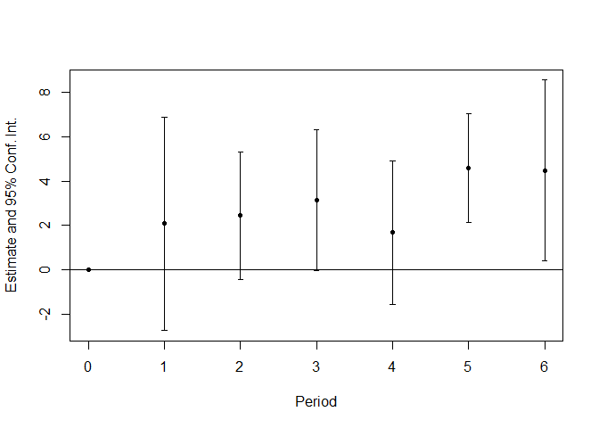

```r
iplot(es.food.data.mortconf.18.65.m2,main=" ",grid=FALSE,xlab="Period")
```

## Difficulty with expenses

### Preparing the analytical sample

```r
load("hps_data_expns_diff.RData")

table(data.expns.dif$WEEK)
```

```
##
##     13     14     15     16     17     18     19     20     21     22     23
## 109051 110019  99302  95604  88716  58729  71939  72484  69944  68348  80567
##     24     25     26     27     28     29     30     31     32     33     34
##  77122  77788  78306  77104  68913  78467  72897  70854  68067  66262  64562
##     35     36     37     38     39     40     41     42     43     44     45
##  68799  69114  63536  59833  57064  60826  74995  75482  84158  63769  61767
##     46     47
##  62826  58304
```

```r
###Age variable
data.expns.dif$AGE<-2022-data.expns.dif$TBIRTH_YEAR

###Create Period
data.expns.dif<- data.expns.dif %>% filter(WEEK<=40,)

data.expns.dif$Period <- as.factor(ifelse(data.expns.dif$WEEK >=1 & data.expns.dif$WEEK <=9, '1.April-June,2020',
                                          ifelse(data.expns.dif$WEEK >=10 & data.expns.dif$WEEK <=15, '2.July-September,2020',
                                                 ifelse(data.expns.dif$WEEK >=16 & data.expns.dif$WEEK <=21, '3.October-December,2020',
                                                        ifelse(data.expns.dif$WEEK >=22 & data.expns.dif$WEEK <=27, '4.January-March,2021',
                                                               ifelse(data.expns.dif$WEEK >=28 & data.expns.dif$WEEK <=33, '5.April-June,2021',
                                                                      ifelse(data.expns.dif$WEEK >=34 & data.expns.dif$WEEK <=38, '6.July-September,2021','7.October-December,2021')))))))


table(data.expns.dif$Period)
```

```
##
##   2.July-September,2020 3.October-December,2020    4.January-March,2021
##                  318372                  457416                  459235
##       5.April-June,2021   6.July-September,2021 7.October-December,2021
##                  425460                  325844                  117890
```

```r
#################### Target Population #####################

##Disabled Identification

#Selecting people aged 18-64 and those who responded to the Medicare question
data.expns.dif.18.65<-data.expns.dif %>% filter(AGE>=18 & AGE<=64 & HLTHINS3>=0)

data.expns.dif.18.65$expns_dif<-ifelse(data.expns.dif.18.65$EXPNS_DIF==3|data.expns.dif.18.65$EXPNS_DIF==4,1,0)
table(data.expns.dif.18.65$expns_dif,exclude = NULL)
```

```
##
##      0      1
## 811516 294670
```

```r
data.expns.dif.18.65$expns_dif<-(data.expns.dif.18.65$expns_dif)*100
table(data.expns.dif.18.65$expns_dif)
```

```
##
##      0    100
## 811516 294670
```

```r
##Creating a disability dummy
data.expns.dif.18.65$MDCR.DIS<-ifelse(data.expns.dif.18.65$HLTHINS3==1,"Disabled","Not-disabled")
table(data.expns.dif.18.65$MDCR.DIS,exclude=NULL)
```

```
##
##     Disabled Not-disabled
##        59554      1046632
```

```r
##Releveling to make the non-disabled the reference category
data.expns.dif.18.65$MDCR.DIS<-relevel(factor(data.expns.dif.18.65$MDCR.DIS),ref="Not-disabled")
table(data.expns.dif.18.65$EXPNS_DIF,exclude = NULL)
```

```
##
##    -99      1      2      3      4
##   1362 568804 241350 168457 126213
```

```r
##Creating difficulty with expenses dummy
data.expns.dif.18.65<-data.expns.dif.18.65 %>% filter(EXPNS_DIF>=0,)

data.expns.dif.18.65$expns_dif<-ifelse(data.expns.dif.18.65$EXPNS_DIF==3|data.expns.dif.18.65$EXPNS_DIF==4,1,0)
table(data.expns.dif.18.65$expns_dif,exclude = NULL)
```

```
##
##      0      1
## 810154 294670
```

```r
##Multiplying food insufficiency by 100 to create percentages
data.expns.dif.18.65$expns_dif<-(data.expns.dif.18.65$expns_dif)*100
table(data.expns.dif.18.65$expns_dif)
```

```
##
##      0    100
## 810154 294670
```

### Descriptive Findings

```r
##Overall Sample
table1(~ expns_dif+factor(EGENDER)+factor(RRACE)+factor(INCOME)+factor(RHISPANIC)+AGE+factor(TENURE)+factor(MS)+factor(EEDUC)+THHLD_NUMKID+THHLD_NUMPER| MDCR.DIS, data.expns.dif.18.65,overall = FALSE)
```

|  | Not-disabled (N=1045457) | Disabled (N=59367) |
| --- | --- | --- |
| expns_dif |  |  |
| Mean (SD) | 25.7 (43.7) | 44.6 (49.7) |
| Median [Min, Max] | 0 [0, 100] | 0 [0, 100] |
| factor(EGENDER) |  |  |
| 1 | 403351 (38.6%) | 19398 (32.7%) |
| 2 | 642106 (61.4%) | 39969 (67.3%) |
| factor(RRACE) |  |  |
| 1 | 845493 (80.9%) | 45013 (75.8%) |
| 2 | 82674 (7.9%) | 7161 (12.1%) |
| 3 | 60351 (5.8%) | 2827 (4.8%) |
| 4 | 56939 (5.4%) | 4366 (7.4%) |
| factor(INCOME) |  |  |
| -99 | 18680 (1.8%) | 1351 (2.3%) |
| -88 | 64110 (6.1%) | 4028 (6.8%) |
| 1 | 87401 (8.4%) | 18476 (31.1%) |
| 2 | 72019 (6.9%) | 7400 (12.5%) |
| 3 | 93829 (9.0%) | 6411 (10.8%) |
| 4 | 157788 (15.1%) | 8246 (13.9%) |
| 5 | 140150 (13.4%) | 5049 (8.5%) |
| 6 | 192636 (18.4%) | 4824 (8.1%) |
| 7 | 98631 (9.4%) | 1877 (3.2%) |
| 8 | 120213 (11.5%) | 1705 (2.9%) |
| factor(RHISPANIC) |  |  |
| 1 | 936257 (89.6%) | 52825 (89.0%) |
| 2 | 109200 (10.4%) | 6542 (11.0%) |
| AGE |  |  |
| Mean (SD) | 45.6 (11.1) | 53.1 (9.87) |
| Median [Min, Max] | 46.0 [19.0, 64.0] | 56.0 [19.0, 64.0] |
| factor(TENURE) |  |  |
| -99 | 3576 (0.3%) | 430 (0.7%) |
| -88 | 27501 (2.6%) | 1959 (3.3%) |
| 1 | 167317 (16.0%) | 14319 (24.1%) |
| 2 | 552435 (52.8%) | 22418 (37.8%) |
| 3 | 281444 (26.9%) | 19080 (32.1%) |
| 4 | 13184 (1.3%) | 1161 (2.0%) |
| factor(MS) |  |  |
| -99 | 3794 (0.4%) | 490 (0.8%) |
| 1 | 610817 (58.4%) | 27093 (45.6%) |
| 2 | 16364 (1.6%) | 3041 (5.1%) |
| 3 | 138841 (13.3%) | 13649 (23.0%) |
| 4 | 20566 (2.0%) | 2037 (3.4%) |
| 5 | 255075 (24.4%) | 13057 (22.0%) |
| factor(EEDUC) |  |  |
| 1 | 5509 (0.5%) | 847 (1.4%) |
| 2 | 13168 (1.3%) | 1777 (3.0%) |
| 3 | 105509 (10.1%) | 11387 (19.2%) |
| 4 | 213086 (20.4%) | 17624 (29.7%) |
| 5 | 110337 (10.6%) | 8571 (14.4%) |
| 6 | 330767 (31.6%) | 11632 (19.6%) |
| 7 | 267081 (25.5%) | 7529 (12.7%) |
| THHLD_NUMKID |  |  |
| Mean (SD) | 0.850 (1.14) | 0.512 (0.962) |
| Median [Min, Max] | 0 [0, 5.00] | 0 [0, 5.00] |
| THHLD_NUMPER |  |  |
| Mean (SD) | 3.02 (1.51) | 2.81 (1.63) |
| Median [Min, Max] | 3.00 [1.00, 10.0] | 2.00 [1.00, 10.0] |

```r
##Every Period
table1(~ expns_dif+factor(EGENDER)+factor(RRACE)+factor(INCOME)+factor(RHISPANIC)+AGE+factor(TENURE)+factor(MS)+factor(EEDUC)+THHLD_NUMKID+THHLD_NUMPER| Period:MDCR.DIS, data.expns.dif.18.65,overall = FALSE)
```

|  | 2.July-September,2020 Not-disabled (N=164497) | 2.July-September,2020 Disabled (N=8655) | 3.October-December,2020 Not-disabled (N=230921) | 3.October-December,2020 Disabled (N=12638) | 4.January-March,2021 Not-disabled (N=211826) | 4.January-March,2021 Disabled (N=12068) | 5.April-June,2021 Not-disabled (N=205487) | 5.April-June,2021 Disabled (N=11908) | 6.July-September,2021 Not-disabled (N=170377) | 6.July-September,2021 Disabled (N=10363) | 7.October-December,2021 Not-disabled (N=62349) | 7.October-December,2021 Disabled (N=3735) |
| --- | --- | --- | --- | --- | --- | --- | --- | --- | --- | --- | --- | --- |
| expns_dif |  |  |  |  |  |  |  |  |  |  |  |  |
| Mean (SD) | 27.4 (44.6) | 44.0 (49.6) | 28.9 (45.3) | 47.6 (49.9) | 27.5 (44.7) | 48.0 (50.0) | 21.7 (41.2) | 41.0 (49.2) | 22.5 (41.7) | 41.5 (49.3) | 24.3 (42.9) | 44.9 (49.7) |
| Median [Min, Max] | 0 [0, 100] | 0 [0, 100] | 0 [0, 100] | 0 [0, 100] | 0 [0, 100] | 0 [0, 100] | 0 [0, 100] | 0 [0, 100] | 0 [0, 100] | 0 [0, 100] | 0 [0, 100] | 0 [0, 100] |
| factor(EGENDER) |  |  |  |  |  |  |  |  |  |  |  |  |
| 1 | 64796 (39.4%) | 2920 (33.7%) | 88803 (38.5%) | 4122 (32.6%) | 79910 (37.7%) | 3969 (32.9%) | 79528 (38.7%) | 3882 (32.6%) | 65170 (38.3%) | 3276 (31.6%) | 25144 (40.3%) | 1229 (32.9%) |
| 2 | 99701 (60.6%) | 5735 (66.3%) | 142118 (61.5%) | 8516 (67.4%) | 131916 (62.3%) | 8099 (67.1%) | 125959 (61.3%) | 8026 (67.4%) | 105207 (61.7%) | 7087 (68.4%) | 37205 (59.7%) | 2506 (67.1%) |
| factor(RRACE) |  |  |  |  |  |  |  |  |  |  |  |  |
| 1 | 131776 (80.1%) | 6415 (74.1%) | 188726 (81.7%) | 9646 (76.3%) | 171716 (81.1%) | 9137 (75.7%) | 165306 (80.4%) | 9006 (75.6%) | 137502 (80.7%) | 7907 (76.3%) | 50467 (80.9%) | 2902 (77.7%) |
| 2 | 13730 (8.3%) | 1104 (12.8%) | 17282 (7.5%) | 1459 (11.5%) | 16520 (7.8%) | 1423 (11.8%) | 16383 (8.0%) | 1468 (12.3%) | 13933 (8.2%) | 1293 (12.5%) | 4826 (7.7%) | 414 (11.1%) |
| 3 | 9607 (5.8%) | 484 (5.6%) | 12149 (5.3%) | 558 (4.4%) | 11955 (5.6%) | 606 (5.0%) | 12803 (6.2%) | 582 (4.9%) | 10061 (5.9%) | 452 (4.4%) | 3776 (6.1%) | 145 (3.9%) |
| 4 | 9384 (5.7%) | 652 (7.5%) | 12764 (5.5%) | 975 (7.7%) | 11635 (5.5%) | 902 (7.5%) | 10995 (5.4%) | 852 (7.2%) | 8881 (5.2%) | 711 (6.9%) | 3280 (5.3%) | 274 (7.3%) |
| factor(INCOME) |  |  |  |  |  |  |  |  |  |  |  |  |
| -99 | 3035 (1.8%) | 221 (2.6%) | 3953 (1.7%) | 274 (2.2%) | 3866 (1.8%) | 256 (2.1%) | 3982 (1.9%) | 272 (2.3%) | 2891 (1.7%) | 257 (2.5%) | 953 (1.5%) | 71 (1.9%) |
| -88 | 8913 (5.4%) | 533 (6.2%) | 12473 (5.4%) | 748 (5.9%) | 11320 (5.3%) | 689 (5.7%) | 15342 (7.5%) | 971 (8.2%) | 12034 (7.1%) | 834 (8.0%) | 4028 (6.5%) | 253 (6.8%) |
| 1 | 13775 (8.4%) | 2585 (29.9%) | 18965 (8.2%) | 3845 (30.4%) | 17596 (8.3%) | 3708 (30.7%) | 16550 (8.1%) | 3822 (32.1%) | 14618 (8.6%) | 3219 (31.1%) | 5897 (9.5%) | 1297 (34.7%) |
| 2 | 11329 (6.9%) | 1082 (12.5%) | 16084 (7.0%) | 1619 (12.8%) | 14787 (7.0%) | 1531 (12.7%) | 13739 (6.7%) | 1471 (12.4%) | 11514 (6.8%) | 1228 (11.8%) | 4566 (7.3%) | 469 (12.6%) |
| 3 | 15285 (9.3%) | 953 (11.0%) | 21180 (9.2%) | 1323 (10.5%) | 19634 (9.3%) | 1380 (11.4%) | 17422 (8.5%) | 1241 (10.4%) | 14668 (8.6%) | 1156 (11.2%) | 5640 (9.0%) | 358 (9.6%) |
| 4 | 25298 (15.4%) | 1225 (14.2%) | 35425 (15.3%) | 1830 (14.5%) | 33066 (15.6%) | 1742 (14.4%) | 29983 (14.6%) | 1606 (13.5%) | 24708 (14.5%) | 1366 (13.2%) | 9308 (14.9%) | 477 (12.8%) |
| 5 | 22707 (13.8%) | 759 (8.8%) | 31716 (13.7%) | 1115 (8.8%) | 28706 (13.6%) | 1027 (8.5%) | 26820 (13.1%) | 939 (7.9%) | 22081 (13.0%) | 881 (8.5%) | 8120 (13.0%) | 328 (8.8%) |
| 6 | 30243 (18.4%) | 764 (8.8%) | 43243 (18.7%) | 1077 (8.5%) | 39114 (18.5%) | 1005 (8.3%) | 37635 (18.3%) | 889 (7.5%) | 31377 (18.4%) | 810 (7.8%) | 11024 (17.7%) | 279 (7.5%) |
| 7 | 15328 (9.3%) | 289 (3.3%) | 21855 (9.5%) | 425 (3.4%) | 19842 (9.4%) | 395 (3.3%) | 19606 (9.5%) | 362 (3.0%) | 16268 (9.5%) | 317 (3.1%) | 5732 (9.2%) | 89 (2.4%) |
| 8 | 18584 (11.3%) | 244 (2.8%) | 26027 (11.3%) | 382 (3.0%) | 23895 (11.3%) | 335 (2.8%) | 24408 (11.9%) | 335 (2.8%) | 20218 (11.9%) | 295 (2.8%) | 7081 (11.4%) | 114 (3.1%) |
| factor(RHISPANIC) |  |  |  |  |  |  |  |  |  |  |  |  |
| 1 | 147635 (89.7%) | 7613 (88.0%) | 208200 (90.2%) | 11343 (89.8%) | 188243 (88.9%) | 10671 (88.4%) | 183916 (89.5%) | 10556 (88.6%) | 152409 (89.5%) | 9296 (89.7%) | 55854 (89.6%) | 3346 (89.6%) |
| 2 | 16862 (10.3%) | 1042 (12.0%) | 22721 (9.8%) | 1295 (10.2%) | 23583 (11.1%) | 1397 (11.6%) | 21571 (10.5%) | 1352 (11.4%) | 17968 (10.5%) | 1067 (10.3%) | 6495 (10.4%) | 389 (10.4%) |
| AGE |  |  |  |  |  |  |  |  |  |  |  |  |
| Mean (SD) | 45.0 (11.1) | 52.5 (10.2) | 45.3 (11.0) | 52.7 (10.0) | 45.9 (11.2) | 53.2 (9.83) | 46.3 (11.0) | 53.4 (9.66) | 45.7 (11.3) | 53.5 (9.75) | 45.2 (11.6) | 53.7 (9.74) |
| Median [Min, Max] | 45.0 [20.0, 64.0] | 56.0 [20.0, 64.0] | 45.0 [20.0, 64.0] | 56.0 [20.0, 64.0] | 46.0 [19.0, 64.0] | 56.0 [19.0, 64.0] | 46.0 [19.0, 64.0] | 56.0 [19.0, 64.0] | 46.0 [19.0, 64.0] | 57.0 [19.0, 64.0] | 45.0 [19.0, 64.0] | 57.0 [19.0, 64.0] |
| factor(TENURE) |  |  |  |  |  |  |  |  |  |  |  |  |
| -99 | 540 (0.3%) | 56 (0.6%) | 629 (0.3%) | 74 (0.6%) | 705 (0.3%) | 80 (0.7%) | 862 (0.4%) | 100 (0.8%) | 641 (0.4%) | 88 (0.8%) | 199 (0.3%) | 32 (0.9%) |
| -88 | 3284 (2.0%) | 245 (2.8%) | 4775 (2.1%) | 347 (2.7%) | 4233 (2.0%) | 304 (2.5%) | 7449 (3.6%) | 510 (4.3%) | 5795 (3.4%) | 426 (4.1%) | 1965 (3.2%) | 127 (3.4%) |
| 1 | 24232 (14.7%) | 2042 (23.6%) | 34304 (14.9%) | 2905 (23.0%) | 33444 (15.8%) | 2944 (24.4%) | 34845 (17.0%) | 2923 (24.5%) | 29808 (17.5%) | 2566 (24.8%) | 10684 (17.1%) | 939 (25.1%) |
| 2 | 87085 (52.9%) | 3336 (38.5%) | 123868 (53.6%) | 4893 (38.7%) | 114511 (54.1%) | 4707 (39.0%) | 107098 (52.1%) | 4307 (36.2%) | 88715 (52.1%) | 3905 (37.7%) | 31158 (50.0%) | 1270 (34.0%) |
| 3 | 47211 (28.7%) | 2803 (32.4%) | 64300 (27.8%) | 4175 (33.0%) | 56238 (26.5%) | 3779 (31.3%) | 52821 (25.7%) | 3844 (32.3%) | 43347 (25.4%) | 3181 (30.7%) | 17527 (28.1%) | 1298 (34.8%) |
| 4 | 2145 (1.3%) | 173 (2.0%) | 3045 (1.3%) | 244 (1.9%) | 2695 (1.3%) | 254 (2.1%) | 2412 (1.2%) | 224 (1.9%) | 2071 (1.2%) | 197 (1.9%) | 816 (1.3%) | 69 (1.8%) |
| factor(MS) |  |  |  |  |  |  |  |  |  |  |  |  |
| -99 | 607 (0.4%) | 70 (0.8%) | 786 (0.3%) | 95 (0.8%) | 846 (0.4%) | 108 (0.9%) | 807 (0.4%) | 122 (1.0%) | 563 (0.3%) | 68 (0.7%) | 185 (0.3%) | 27 (0.7%) |
| 1 | 94577 (57.5%) | 3973 (45.9%) | 134953 (58.4%) | 5784 (45.8%) | 124217 (58.6%) | 5521 (45.7%) | 121750 (59.2%) | 5266 (44.2%) | 99945 (58.7%) | 4869 (47.0%) | 35375 (56.7%) | 1680 (45.0%) |
| 2 | 2250 (1.4%) | 387 (4.5%) | 3269 (1.4%) | 628 (5.0%) | 3398 (1.6%) | 626 (5.2%) | 3422 (1.7%) | 626 (5.3%) | 2910 (1.7%) | 563 (5.4%) | 1115 (1.8%) | 211 (5.6%) |
| 3 | 21572 (13.1%) | 2003 (23.1%) | 30470 (13.2%) | 2831 (22.4%) | 28178 (13.3%) | 2737 (22.7%) | 27514 (13.4%) | 2870 (24.1%) | 22734 (13.3%) | 2317 (22.4%) | 8373 (13.4%) | 891 (23.9%) |
| 4 | 3363 (2.0%) | 327 (3.8%) | 4583 (2.0%) | 435 (3.4%) | 4176 (2.0%) | 414 (3.4%) | 4069 (2.0%) | 388 (3.3%) | 3226 (1.9%) | 346 (3.3%) | 1149 (1.8%) | 127 (3.4%) |
| 5 | 42128 (25.6%) | 1895 (21.9%) | 56860 (24.6%) | 2865 (22.7%) | 51011 (24.1%) | 2662 (22.1%) | 47925 (23.3%) | 2636 (22.1%) | 40999 (24.1%) | 2200 (21.2%) | 16152 (25.9%) | 799 (21.4%) |
| factor(EEDUC) |  |  |  |  |  |  |  |  |  |  |  |  |
| 1 | 871 (0.5%) | 124 (1.4%) | 1116 (0.5%) | 151 (1.2%) | 1203 (0.6%) | 178 (1.5%) | 1104 (0.5%) | 172 (1.4%) | 853 (0.5%) | 158 (1.5%) | 362 (0.6%) | 64 (1.7%) |
| 2 | 2218 (1.3%) | 315 (3.6%) | 2802 (1.2%) | 357 (2.8%) | 2841 (1.3%) | 349 (2.9%) | 2557 (1.2%) | 366 (3.1%) | 1981 (1.2%) | 296 (2.9%) | 769 (1.2%) | 94 (2.5%) |
| 3 | 17591 (10.7%) | 1716 (19.8%) | 23086 (10.0%) | 2346 (18.6%) | 21119 (10.0%) | 2272 (18.8%) | 20273 (9.9%) | 2259 (19.0%) | 17091 (10.0%) | 2013 (19.4%) | 6349 (10.2%) | 781 (20.9%) |
| 4 | 34144 (20.8%) | 2529 (29.2%) | 47853 (20.7%) | 3761 (29.8%) | 43431 (20.5%) | 3566 (29.5%) | 40524 (19.7%) | 3593 (30.2%) | 34731 (20.4%) | 3022 (29.2%) | 12403 (19.9%) | 1153 (30.9%) |
| 5 | 17174 (10.4%) | 1197 (13.8%) | 24697 (10.7%) | 1898 (15.0%) | 22688 (10.7%) | 1753 (14.5%) | 21268 (10.4%) | 1731 (14.5%) | 18103 (10.6%) | 1461 (14.1%) | 6407 (10.3%) | 531 (14.2%) |
| 6 | 51938 (31.6%) | 1709 (19.7%) | 73805 (32.0%) | 2556 (20.2%) | 66895 (31.6%) | 2364 (19.6%) | 65038 (31.7%) | 2296 (19.3%) | 53400 (31.3%) | 2016 (19.5%) | 19691 (31.6%) | 691 (18.5%) |
| 7 | 40561 (24.7%) | 1065 (12.3%) | 57562 (24.9%) | 1569 (12.4%) | 53649 (25.3%) | 1586 (13.1%) | 54723 (26.6%) | 1491 (12.5%) | 44218 (26.0%) | 1397 (13.5%) | 16368 (26.3%) | 421 (11.3%) |
| THHLD_NUMKID |  |  |  |  |  |  |  |  |  |  |  |  |
| Mean (SD) | 0.898 (1.16) | 0.566 (0.990) | 0.893 (1.16) | 0.565 (1.01) | 0.844 (1.13) | 0.513 (0.956) | 0.826 (1.12) | 0.484 (0.926) | 0.810 (1.12) | 0.461 (0.938) | 0.772 (1.11) | 0.435 (0.897) |
| Median [Min, Max] | 0 [0, 5.00] | 0 [0, 5.00] | 0 [0, 5.00] | 0 [0, 5.00] | 0 [0, 5.00] | 0 [0, 5.00] | 0 [0, 5.00] | 0 [0, 5.00] | 0 [0, 5.00] | 0 [0, 5.00] | 0 [0, 5.00] | 0 [0, 5.00] |
| THHLD_NUMPER |  |  |  |  |  |  |  |  |  |  |  |  |
| Mean (SD) | 3.05 (1.52) | 2.90 (1.67) | 3.06 (1.52) | 2.89 (1.66) | 3.04 (1.50) | 2.83 (1.64) | 3.01 (1.49) | 2.75 (1.58) | 3.00 (1.50) | 2.76 (1.61) | 2.90 (1.50) | 2.63 (1.57) |
| Median [Min, Max] | 3.00 [1.00, 10.0] | 2.00 [1.00, 10.0] | 3.00 [1.00, 10.0] | 2.00 [1.00, 10.0] | 3.00 [1.00, 10.0] | 2.00 [1.00, 10.0] | 3.00 [1.00, 10.0] | 2.00 [1.00, 10.0] | 3.00 [1.00, 10.0] | 2.00 [1.00, 10.0] | 3.00 [1.00, 10.0] | 2.00 [1.00, 10.0] |

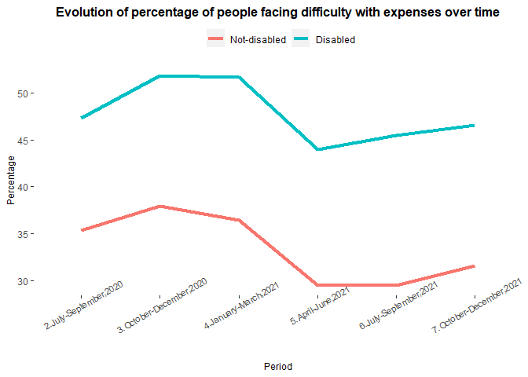

```r
#### Without error bars, Weighted
data.expns.dif.18.65 %>% group_by(Period,MDCR.DIS) %>%
  summarise(count=n(),w.mean.expns_dif=weighted.mean(expns_dif,PWEIGHT)) %>%
  ggplot(aes(group=factor(MDCR.DIS),fill=factor(MDCR.DIS),color=factor(MDCR.DIS), y=w.mean.expns_dif , x=factor(Period))) +
  geom_line(size=1.5)+
  labs(title ="Evolution of percentage of people facing difficulty with expenses over time",y="Percentage",x="Period")+
  theme(axis.text.x = element_text(size=8, angle=30),
        panel.background=element_blank(),
        plot.title    = element_text(face = "bold",   size = 12, hjust = 0.5),
        axis.text.y   = element_text(size=9),
        axis.title.x   = element_text(size=9),
        axis.title.y  = element_text(size=9),
        legend.text   = element_text(size=9),
        legend.title  = element_blank(),
        legend.position = "top")
```

### Regression Findings

```r
################################### Regression #####################################

##without controls
food.data.expns.dif.18.65.m1<-feols(expns_dif~MDCR.DIS*Period,data=data.expns.dif.18.65,cluster = ~ state_fips,weights = data.expns.dif.18.65$PWEIGHT)
etable(food.data.expns.dif.18.65.m1)
```

```
##                                                  food.data.expns...
## Dependent Var.:                                           expns_dif
##
## (Intercept)                                       35.36*** (0.8385)
## MDCR.DISDisabled                                   11.99*** (1.503)
## Period3.October-December,2020                     2.537*** (0.4355)
## Period4.January-March,2021                          1.049* (0.4563)
## Period5.April-June,2021                          -5.905*** (0.3888)
## Period6.July-September,2021                      -5.867*** (0.4014)
## Period7.October-December,2021                    -3.812*** (0.5762)
## MDCR.DISDisabled x Period3.October-December,2020     1.975. (1.166)
## MDCR.DISDisabled x Period4.January-March,2021        3.248* (1.543)
## MDCR.DISDisabled x Period5.April-June,2021            2.498 (1.639)
## MDCR.DISDisabled x Period6.July-September,2021       4.024* (1.781)
## MDCR.DISDisabled x Period7.October-December,2021     3.003* (1.341)
## ________________________________________         __________________
## S.E.: Clustered                                      by: state_fips
## Observations                                              1,104,824
## R2                                                          0.01124
## Adj. R2                                                     0.01123
## ---
## Signif. codes: 0 '***' 0.001 '**' 0.01 '*' 0.05 '.' 0.1 ' ' 1
```

```r
round(confint(food.data.expns.dif.18.65.m1),digits=2)
```

```
##                                                2.5 % 97.5 %
## (Intercept)                                    33.67  37.04
## MDCR.DISDisabled                                8.97  15.01
## Period3.October-December,2020                   1.66   3.41
## Period4.January-March,2021                      0.13   1.97
## Period5.April-June,2021                        -6.69  -5.12
## Period6.July-September,2021                    -6.67  -5.06
## Period7.October-December,2021                  -4.97  -2.65
## MDCR.DISDisabled:Period3.October-December,2020 -0.37   4.32
## MDCR.DISDisabled:Period4.January-March,2021     0.15   6.35
## MDCR.DISDisabled:Period5.April-June,2021       -0.79   5.79
## MDCR.DISDisabled:Period6.July-September,2021    0.45   7.60
## MDCR.DISDisabled:Period7.October-December,2021  0.31   5.70
```

```r
##with controls
food.data.expns.dif.18.65.m2<-feols(expns_dif~MDCR.DIS*Period+factor(state_fips)+factor(EGENDER)+factor(INCOME)+factor(RRACE)+factor(RHISPANIC)+AGE+factor(TENURE)+factor(MS)+factor(EEDUC)+factor(THHLD_NUMKID)+factor(THHLD_NUMPER),
                                    data=data.expns.dif.18.65,cluster = ~ state_fips ,weights = data.expns.dif.18.65$PWEIGHT)
etable(food.data.expns.dif.18.65.m2)
```

```
##                                                  food.data.expns.d..
## Dependent Var.:                                            expns_dif
##
## (Intercept)                                         25.31*** (1.899)
## MDCR.DISDisabled                                      1.082 (0.8381)
## Period3.October-December,2020                      2.646*** (0.3755)
## Period4.January-March,2021                          1.155** (0.4003)
## Period5.April-June,2021                           -5.218*** (0.3571)
## Period6.July-September,2021                       -5.037*** (0.3591)
## Period7.October-December,2021                     -3.408*** (0.5344)
## factor(state_fips)2                               -2.603*** (0.1775)
## factor(state_fips)4                               -1.617*** (0.1114)
## factor(state_fips)5                               -1.089*** (0.0430)
## factor(state_fips)6                              -0.9198*** (0.1458)
## factor(state_fips)8                              -0.9349*** (0.1352)
## factor(state_fips)9                                1.660*** (0.1210)
## factor(state_fips)10                              -1.447*** (0.0842)
## factor(state_fips)11                              -2.987*** (0.2104)
## factor(state_fips)12                               0.2687** (0.0845)
## factor(state_fips)13                             -0.3170*** (0.0427)
## factor(state_fips)15                                 0.4965 (0.3928)
## factor(state_fips)16                              -6.877*** (0.1006)
## factor(state_fips)17                             -0.9422*** (0.0972)
## factor(state_fips)18                              -2.490*** (0.0764)
## factor(state_fips)19                              -4.294*** (0.1164)
## factor(state_fips)20                              -4.226*** (0.1049)
## factor(state_fips)21                             -0.9905*** (0.0639)
## factor(state_fips)22                               2.993*** (0.0433)
## factor(state_fips)23                              -3.865*** (0.1373)
## factor(state_fips)24                              -1.020*** (0.0936)
## factor(state_fips)25                             -0.6730*** (0.1499)
## factor(state_fips)26                              -2.847*** (0.0722)
## factor(state_fips)27                              -4.916*** (0.1546)
## factor(state_fips)28                              0.9153*** (0.0782)
## factor(state_fips)29                              -2.625*** (0.0831)
## factor(state_fips)30                              -4.886*** (0.1241)
## factor(state_fips)31                              -4.408*** (0.1202)
## factor(state_fips)32                              0.7873*** (0.1043)
## factor(state_fips)33                              -1.963*** (0.1416)
## factor(state_fips)34                               1.988*** (0.1387)
```

[output cut: 62 more lines]

```
## factor(THHLD_NUMPER)8                               17.06*** (1.521)
## factor(THHLD_NUMPER)9                               17.39*** (1.559)
## factor(THHLD_NUMPER)10                              17.73*** (2.159)
## MDCR.DISDisabled x Period3.October-December,2020      1.613 (0.9972)
## MDCR.DISDisabled x Period4.January-March,2021         2.824* (1.399)
## MDCR.DISDisabled x Period5.April-June,2021             1.320 (1.188)
## MDCR.DISDisabled x Period6.July-September,2021        3.192* (1.516)
## MDCR.DISDisabled x Period7.October-December,2021      2.379. (1.384)
## ________________________________________         ___________________
## S.E.: Clustered                                       by: state_fips
## Observations                                               1,104,824
## R2                                                           0.19359
## Adj. R2                                                      0.19351
## ---
## Signif. codes: 0 '***' 0.001 '**' 0.01 '*' 0.05 '.' 0.1 ' ' 1
```

```r
round(confint(food.data.expns.dif.18.65.m2),digits=2)
```

```
##                                                 2.5 % 97.5 %
## (Intercept)                                     21.49  29.12
## MDCR.DISDisabled                                -0.60   2.77
## Period3.October-December,2020                    1.89   3.40
## Period4.January-March,2021                       0.35   1.96
## Period5.April-June,2021                         -5.94  -4.50
## Period6.July-September,2021                     -5.76  -4.32
## Period7.October-December,2021                   -4.48  -2.33
## factor(state_fips)2                             -2.96  -2.25
## factor(state_fips)4                             -1.84  -1.39
## factor(state_fips)5                             -1.18  -1.00
## factor(state_fips)6                             -1.21  -0.63
## factor(state_fips)8                             -1.21  -0.66
## factor(state_fips)9                              1.42   1.90
## factor(state_fips)10                            -1.62  -1.28
## factor(state_fips)11                            -3.41  -2.56
## factor(state_fips)12                             0.10   0.44
## factor(state_fips)13                            -0.40  -0.23
## factor(state_fips)15                            -0.29   1.29
## factor(state_fips)16                            -7.08  -6.68
## factor(state_fips)17                            -1.14  -0.75
## factor(state_fips)18                            -2.64  -2.34
## factor(state_fips)19                            -4.53  -4.06
## factor(state_fips)20                            -4.44  -4.02
## factor(state_fips)21                            -1.12  -0.86
## factor(state_fips)22                             2.91   3.08
## factor(state_fips)23                            -4.14  -3.59
## factor(state_fips)24                            -1.21  -0.83
## factor(state_fips)25                            -0.97  -0.37
## factor(state_fips)26                            -2.99  -2.70
## factor(state_fips)27                            -5.23  -4.61
## factor(state_fips)28                             0.76   1.07
## factor(state_fips)29                            -2.79  -2.46
## factor(state_fips)30                            -5.14  -4.64
## factor(state_fips)31                            -4.65  -4.17
## factor(state_fips)32                             0.58   1.00
## factor(state_fips)33                            -2.25  -1.68
## factor(state_fips)34                             1.71   2.27
## factor(state_fips)35                            -1.50  -0.92
## factor(state_fips)36                             0.56   1.01
```

[output cut: 53 more lines]

```
## factor(THHLD_NUMKID)5                            1.11   5.16
## factor(THHLD_NUMPER)2                            4.67   6.60
## factor(THHLD_NUMPER)3                            7.49   9.77
## factor(THHLD_NUMPER)4                            8.55  11.19
## factor(THHLD_NUMPER)5                           11.05  13.35
## factor(THHLD_NUMPER)6                           12.44  15.86
## factor(THHLD_NUMPER)7                           15.14  19.37
## factor(THHLD_NUMPER)8                           14.01  20.12
## factor(THHLD_NUMPER)9                           14.26  20.52
## factor(THHLD_NUMPER)10                          13.39  22.06
## MDCR.DISDisabled:Period3.October-December,2020  -0.39   3.62
## MDCR.DISDisabled:Period4.January-March,2021      0.01   5.63
## MDCR.DISDisabled:Period5.April-June,2021        -1.07   3.71
## MDCR.DISDisabled:Period6.July-September,2021     0.15   6.24
## MDCR.DISDisabled:Period7.October-December,2021  -0.40   5.16
```

```r
########################### Event Study Graphs ############################

##without controls
data.expns.dif.18.65$Period.num<-as.integer(data.expns.dif.18.65$Period)
data.expns.dif.18.65$PeriodN<-(data.expns.dif.18.65$Period.num)-1
data.expns.dif.18.65$state_fips<-as.factor(data.expns.dif.18.65$state_fips)
data.expns.dif.18.65$treated<-ifelse(data.expns.dif.18.65$MDCR.DIS=="Disabled",1,0)

es.food.data.expns.dif.18.65.m1 <-
  feols(expns_dif ~ i(PeriodN, ref = 0):treated+factor(MDCR.DIS)+factor(PeriodN),
        cluster = ~ state_fips,
        data = data.expns.dif.18.65,
        weights = data.expns.dif.18.65$PWEIGHT)

summary(es.food.data.expns.dif.18.65.m1)
```

```
## OLS estimation, Dep. Var.: expns_dif
## Observations: 1,104,824
## Standard-errors: Clustered (state_fips)
##                          Estimate Std. Error t value   Pr(>|t|)
## (Intercept)                35.358     0.8385  42.169  < 2.2e-16 ***
## factor(MDCR.DIS)Disabled   11.993     1.5032   7.978 1.7994e-10 ***
## factor(PeriodN)1            2.537     0.4355   5.826 4.0745e-07 ***
## factor(PeriodN)2            1.049     0.4563   2.298 2.5791e-02 *
## factor(PeriodN)3           -5.905     0.3888 -15.186  < 2.2e-16 ***
## factor(PeriodN)4           -5.867     0.4014 -14.618  < 2.2e-16 ***
## factor(PeriodN)5           -3.812     0.5762  -6.615 2.3994e-08 ***
## PeriodN::1:treated          1.975     1.1656   1.694 9.6422e-02 .
## PeriodN::2:treated          3.248     1.5429   2.105 4.0352e-02 *
## PeriodN::3:treated          2.498     1.6388   1.524 1.3382e-01
## PeriodN::4:treated          4.024     1.7805   2.260 2.8192e-02 *
## PeriodN::5:treated          3.003     1.3407   2.240 2.9579e-02 *
## ---
## Signif. codes:  0 '***' 0.001 '**' 0.01 '*' 0.05 '.' 0.1 ' ' 1
## RMSE: 2,757.6   Adj. R2: 0.011232
```

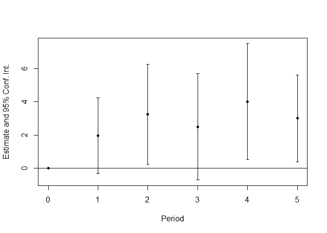

```r
iplot(es.food.data.expns.dif.18.65.m1,main=" ",grid=FALSE,xlab="Period")
```

```r
##with controls
es.food.data.expns.dif.18.65.m2 <-
  feols(expns_dif ~ i(PeriodN, ref = 0):treated+factor(MDCR.DIS)+factor(PeriodN)+factor(state_fips)+factor(EGENDER)+factor(INCOME)+factor(RRACE)+factor(RHISPANIC)+AGE+factor(TENURE)+factor(MS)+factor(EEDUC)+factor(THHLD_NUMKID)+factor(THHLD_NUMPER),
        cluster = ~ state_fips,
        data = data.expns.dif.18.65,
        weights = data.expns.dif.18.65$PWEIGHT)

summary(es.food.data.expns.dif.18.65.m2)
```

```
## OLS estimation, Dep. Var.: expns_dif
## Observations: 1,104,824
## Standard-errors: Clustered (state_fips)
##                            Estimate Std. Error   t value   Pr(>|t|)
## (Intercept)               25.306631    1.89911  13.32554  < 2.2e-16 ***
## factor(MDCR.DIS)Disabled   1.081753    0.83814   1.29066 2.0276e-01
## factor(PeriodN)1           2.646022    0.37555   7.04577 5.0889e-09 ***
## factor(PeriodN)2           1.155297    0.40026   2.88633 5.7412e-03 **
## factor(PeriodN)3          -5.218301    0.35707 -14.61404  < 2.2e-16 ***
## factor(PeriodN)4          -5.036717    0.35906 -14.02748  < 2.2e-16 ***
## factor(PeriodN)5          -3.408158    0.53436  -6.37806 5.6379e-08 ***
## factor(state_fips)2       -2.602915    0.17747 -14.66713  < 2.2e-16 ***
## factor(state_fips)4       -1.617139    0.11140 -14.51693  < 2.2e-16 ***
## factor(state_fips)5       -1.089021    0.04302 -25.31235  < 2.2e-16 ***
## factor(state_fips)6       -0.919838    0.14576  -6.31078 7.1808e-08 ***
## factor(state_fips)8       -0.934950    0.13521  -6.91477 8.1580e-09 ***
## factor(state_fips)9        1.659986    0.12101  13.71714  < 2.2e-16 ***
## factor(state_fips)10      -1.447332    0.08415 -17.19856  < 2.2e-16 ***
## factor(state_fips)11      -2.987308    0.21041 -14.19748  < 2.2e-16 ***
## factor(state_fips)12       0.268662    0.08451   3.17917 2.5351e-03 **
## factor(state_fips)13      -0.316963    0.04271  -7.42093 1.3199e-09 ***
## factor(state_fips)15       0.496549    0.39283   1.26404 2.1208e-01
## factor(state_fips)16      -6.877134    0.10057 -68.38504  < 2.2e-16 ***
## factor(state_fips)17      -0.942242    0.09718  -9.69556 4.5025e-13 ***
## factor(state_fips)18      -2.490012    0.07643 -32.57920  < 2.2e-16 ***
## factor(state_fips)19      -4.293773    0.11637 -36.89820  < 2.2e-16 ***
## factor(state_fips)20      -4.226447    0.10493 -40.28015  < 2.2e-16 ***
## factor(state_fips)21      -0.990485    0.06387 -15.50786  < 2.2e-16 ***
## factor(state_fips)22       2.993170    0.04335  69.04454  < 2.2e-16 ***
## factor(state_fips)23      -3.864807    0.13734 -28.14055  < 2.2e-16 ***
## factor(state_fips)24      -1.019546    0.09362 -10.89044 8.4318e-15 ***
## factor(state_fips)25      -0.673005    0.14988  -4.49014 4.2085e-05 ***
## factor(state_fips)26      -2.846949    0.07218 -39.44437  < 2.2e-16 ***
## factor(state_fips)27      -4.916219    0.15460 -31.79997  < 2.2e-16 ***
## factor(state_fips)28       0.915295    0.07824  11.69815 6.3390e-16 ***
## factor(state_fips)29      -2.624722    0.08306 -31.59909  < 2.2e-16 ***
## factor(state_fips)30      -4.885961    0.12409 -39.37502  < 2.2e-16 ***
## factor(state_fips)31      -4.408383    0.12019 -36.67824  < 2.2e-16 ***
## factor(state_fips)32       0.787316    0.10425   7.55213 8.2428e-10 ***
## factor(state_fips)33      -1.962580    0.14157 -13.86320  < 2.2e-16 ***
```

[output cut: 59 more lines]

```
## factor(THHLD_NUMPER)4      9.871677    0.65590  15.05062  < 2.2e-16 ***
## factor(THHLD_NUMPER)5     12.199887    0.57393  21.25669  < 2.2e-16 ***
## factor(THHLD_NUMPER)6     14.154008    0.85167  16.61909  < 2.2e-16 ***
## factor(THHLD_NUMPER)7     17.253882    1.05464  16.36001  < 2.2e-16 ***
## factor(THHLD_NUMPER)8     17.061348    1.52099  11.21730 2.9291e-15 ***
## factor(THHLD_NUMPER)9     17.389197    1.55870  11.15619 3.5657e-15 ***
## factor(THHLD_NUMPER)10    17.726225    2.15867   8.21165 7.8418e-11 ***
## PeriodN::1:treated         1.612533    0.99721   1.61704 1.1216e-01
## PeriodN::2:treated         2.824324    1.39868   2.01928 4.8835e-02 *
## PeriodN::3:treated         1.319788    1.18775   1.11116 2.7181e-01
## PeriodN::4:treated         3.191826    1.51641   2.10486 4.0351e-02 *
## PeriodN::5:treated         2.378535    1.38440   1.71810 9.1966e-02 .
## ---
## Signif. codes:  0 '***' 0.001 '**' 0.01 '*' 0.05 '.' 0.1 ' ' 1
## RMSE: 2,490.4   Adj. R2: 0.193511
```

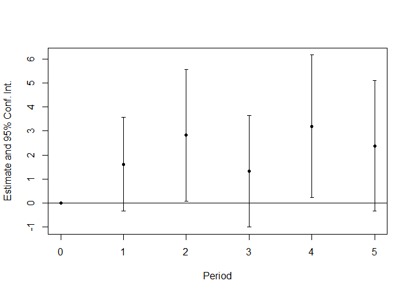

```r
iplot(es.food.data.expns.dif.18.65.m2,main=" ",grid=FALSE,xlab="Period")
```